# Perspectiva de gènere i emprenedoria empresarial a la ciutat de Rubí

Natalia Soto Las

Curs 2022-23

# Cargar los datos

```r
bbdd_original <- readxl::read_excel("RESPUESTAS.xlsx"); colnames(bbdd_original)
```

```
##  [1] "¿Cuál es el nombre de la empresa en la que trabajas?"
##  [2] "¿Eres el/la dueño/a o propietario/a de esta empresa?"
##  [3] "¿Eres uno/a de los/las directores/as de la empresa?"
##  [4] "¿Con qué género te identificas?...4"
##  [5] "¿En qué año naciste? (aaaa)...5"
##  [6] "¿En qué año se te consideró director/a de la empresa? (aaaa)"
##  [7] "¿Cuántos dueños tiene la empresa en la que trabajas?"
##  [8] "¿Con qué género se identifica a los propietarios ya se trate de uno solo o de varios?"
##  [9] "¿Con qué género te identificas?...9"
## [10] "¿En qué año naciste? (aaaa)...10"
## [11] "¿En qué año se te consideró propietario/a de la empresa? (aaaa)...11"
## [12] "¿Cómo llegaste a ser propietario de la empresa?"
## [13] "¿Cuántos propietarios/as tiene la empresa, incluyendote a ti?"
## [14] "¿Con qué género se podría identificar al conjunto de propietarios de la empresa?"
## [15] "¿Con qué género te identificas?...15"
```

[output cut: 38 more lines]

```r
require(dplyr)
# Verificar duplicados en la columna 'empresa'
empresas_duplicadas <- bbdd_original %>%
  group_by(
    `¿Cuál es el nombre de la empresa en la que trabajas?`) %>%
  filter(n() > 1) %>%
  distinct(`¿Cuál es el nombre de la empresa en la que trabajas?`)

# Verificar cambios en los sufijos de las empresas
sufijos <- c("S.L.", "S.A.", "S.L.U.")
empresas_con_sufijos <- bbdd_original %>%
  filter(grepl(paste(sufijos, collapse = "|"),
               `¿Cuál es el nombre de la empresa en la que trabajas?`,
               ignore.case = TRUE))

# Imprimir resultados
if (nrow(empresas_duplicadas) > 0) {
  cat("Empresas duplicadas:\n")
  print(empresas_duplicadas)
} else {
  cat("No se encontraron empresas duplicadas.\n")
}
```

```
## No se encontraron empresas duplicadas.
```

## Eliminar filas que no hayan pasado el filtro

```r
del <- which(bbdd_original$`¿Eres uno/a de los/las directores/as de la empresa?`=="No")
bbdd_sinrespuesta <- bbdd_original[-del,]
```

Donada la dificultat d’obtenir enquestes i per limitació de temps s’ha procedit a fer el mostreig via telefónica o presencial. Pel que no hi ha cap registre amb el filtre pasat.

## Mirar si alguna empresa se repite

```r
duplicados <- duplicated(bbdd_original)
bbdd_original[duplicados,]
```

```
## # A tibble: 0 x 53
## # i 53 variables: ¿Cuál es el nombre de la empresa en la que trabajas? <chr>,
## #   ¿Eres el/la dueño/a o propietario/a de esta empresa? <chr>,
## #   ¿Eres uno/a de los/las directores/as de la empresa? <chr>,
## #   ¿Con qué género te identificas?...4 <chr>,
## #   ¿En qué año naciste? (aaaa)...5 <dbl>,
## #   ¿En qué año se te consideró director/a de la empresa? (aaaa) <dbl>,
## #   ¿Cuántos dueños tiene la empresa en la que trabajas? <chr>, ...
```

NO HAY DUPLICADOS

## Cambiar nombre a las variables

```r
bbdd_sinnombre <- bbdd_original[,-c(1,52,53)]
(colnames(bbdd_sinnombre) <- c("dueno","director",
                              "gen_dir","nac_dir","an_dir","num_dueno","gen_duenos_emp",
                              "gen_un_duen","nac_un_duen","an_un_duen","mot_duen",
                              "num_v_duen","gen_v_duen","gen_v_u_duen","nac_v_u_duen",
                              "an_v_u_duen","mot_v_duen",
                              "zona","fundada","personal","sector","impor","expor",
                              "n.suc","suc_fuera_cat",
                              "ERTO","covid1","covid2","covid3","covid4","covid5",
                              "covid6","covid7","covid8","covid9",
                              "esf1","esf2","esf3","esf4","esf5","esf6","esf7","esf8",
                              "esf9","esf10","NIVEL_ESF",
                              "num_hij","sit_sent","estudios","horas"))
```

```
##  [1] "dueno"          "director"       "gen_dir"        "nac_dir"
##  [5] "an_dir"         "num_dueno"      "gen_duenos_emp" "gen_un_duen"
##  [9] "nac_un_duen"    "an_un_duen"     "mot_duen"       "num_v_duen"
## [13] "gen_v_duen"     "gen_v_u_duen"   "nac_v_u_duen"   "an_v_u_duen"
## [17] "mot_v_duen"     "zona"           "fundada"        "personal"
## [21] "sector"         "impor"          "expor"          "n.suc"
## [25] "suc_fuera_cat"  "ERTO"           "covid1"         "covid2"
## [29] "covid3"         "covid4"         "covid5"         "covid6"
## [33] "covid7"         "covid8"         "covid9"         "esf1"
## [37] "esf2"           "esf3"           "esf4"           "esf5"
## [41] "esf6"           "esf7"           "esf8"           "esf9"
## [45] "esf10"          "NIVEL_ESF"      "num_hij"        "sit_sent"
## [49] "estudios"       "horas"
```

# Manipulación de los datos

## Dueño

```r
duen <- as.numeric()
for(i in 1:nrow(bbdd_sinnombre)){
  if(bbdd_sinnombre$dueno[i]=="No"){duen[i]<-0}
  if(bbdd_sinnombre$dueno[i]=="Sí, soy el/la único/a dueño/a"){duen[i]<-1}
  if(bbdd_sinnombre$dueno[i]=="Sí, comparto la empresa con más personas"){duen[i]<-2}
};table(duen)
```

```
## duen
##  0  1  2
## 11 33 31
```

## Juntar variables de género de la persona que contesta

```r
gen <- as.numeric(nrow(bbdd_sinnombre))

fem <- c(which(bbdd_sinnombre$gen_dir=="Femenino"),
         which(bbdd_sinnombre$gen_un_duen=="Femenino"),
         which(bbdd_sinnombre$gen_v_u_duen=="Femenino"))
mas <- c(which(bbdd_sinnombre$gen_dir=="Masculino"),
         which(bbdd_sinnombre$gen_un_duen=="Masculino"),
         which(bbdd_sinnombre$gen_v_u_duen=="Masculino"))

gen[fem] <- "f";gen[mas] <- "m"
table(gen)
```

```
## gen
##  f  m
## 34 41
```

## Juntar variables de género de la empresa

```r
gen_emp <- as.numeric(nrow(bbdd_sinnombre))

fem <- c(which(bbdd_sinnombre$gen_duenos_emp=="Femenino"),
         which(bbdd_sinnombre$gen_v_duen=="Todo femenino"),
         which(bbdd_sinnombre$gen_un_duen=="Femenino"))
mas <- c(which(bbdd_sinnombre$gen_duenos_emp=="Masculino"),
         which(bbdd_sinnombre$gen_v_duen=="Todo masculino"),
         which(bbdd_sinnombre$gen_un_duen=="Masculino"))
mix <- c(which(bbdd_sinnombre$gen_duenos_emp=="Mixto"),
         which(bbdd_sinnombre$gen_v_duen=="Mixto"),
         which(bbdd_sinnombre$gen_un_duen=="Neutro"))

gen_emp[fem] <- "f"; gen_emp[mas] <- "m"; gen_emp[mix] <- "x"

table(gen_emp)
round(table(gen_emp)/nrow(bbdd_sinnombre)*100,2)
```

```
## gen_emp
##  f  m  x
## 17 30 28
## gen_emp
##     f     m     x
## 22.67 40.00 37.33
```

## Año de nacimiento de la persona que contesta

```r
nacimiento <- as.numeric(nrow(bbdd_sinnombre))

dir <- which(bbdd_sinnombre$nac_dir!="NA")
un_duen <- which(bbdd_sinnombre$nac_un_duen!="NA")
v_duen <- which(bbdd_sinnombre$nac_v_u_duen!="NA")

nacimiento[dir] <- bbdd_sinnombre$nac_dir[dir]
nacimiento[un_duen] <- bbdd_sinnombre$nac_un_duen[un_duen]
nacimiento[v_duen] <- bbdd_sinnombre$nac_v_u_duen[v_duen]

nacimiento
```

```
##  [1] 1998 1962 1977 1965 1971 1977 1982 1978 1972 1978 1986 1964 1964 1957 1976
## [16] 1969 1990 1968 1979 1970 1971 1965 1984 1978 1952 1957 1977 1964 1962 1964
## [31] 1952 1965 1995 1962 1959 1972 1955 1953 1962 1964 1966 1977 1961 1971 1958
## [46] 1959 1960 1974 1971 1979 1991 1966 1964 1955 1958 1962 1963 1968 1980 1999
## [61] 1988 1968 1968 1962 1979 1979 1961 1966 1973 1977 1993 1960 1976 1989 1987
```

## Año al que accedió al puesto

```r
ano_acceso <- as.numeric(nrow(bbdd_sinnombre))

dir <- which(bbdd_sinnombre$an_dir!="NA")
un_duen <- which(bbdd_sinnombre$an_un_duen!="NA")
v_duen <- which(bbdd_sinnombre$an_v_u_duen!="NA")

ano_acceso[dir] <- bbdd_sinnombre$an_dir[dir]
ano_acceso[un_duen] <- bbdd_sinnombre$an_un_duen[un_duen]
ano_acceso[v_duen] <- bbdd_sinnombre$an_v_u_duen[v_duen]

ano_acceso
```

```
##  [1] 2022 2012 2002 1997 2018 2002 2004 1999 2010 2018 2016 1989 1992 1981 2011
## [16] 2010 2013 2015 2010 2012 2007 2015 2020 2012 1977 1980 1996 1988 2000 2014
## [31] 2010 2013 2022 2006 2022 2013 2007 2011 1996 1996 1986 2018 2006 2000 1994
## [46] 1999 2005 2014 2010 2008 2020 1988 2022 1990 1997 2004 2000 2003 2010 2020
## [61] 2017 1992 2005 1985 2018 2019 2013 2007 2020 1994 2015 1998 1994 2010 2008
```

## Numero de dueños de la empresa

```r
num_duenos <- as.numeric(nrow(bbdd_sinnombre))

dir <- which(bbdd_sinnombre$dueno=="Sí, soy el/la único/a dueño/a")
un_duen <- which(bbdd_sinnombre$num_dueno!="NA")
v_duen <- which(bbdd_sinnombre$num_v_duen!="NA")

num_duenos[dir] <- "Solo una persona es dueña de la empresa"
num_duenos[un_duen] <- bbdd_sinnombre$num_dueno[un_duen]
num_duenos[v_duen] <- "Hay varias personas que son dueñas de la empresa"

un_duen <- which(num_duenos=="Solo una persona es dueña de la empresa")
v_duen <- which(num_duenos=="Hay varias personas que son dueñas de la empresa")

num_duenos[un_duen] <- "u"; num_duenos[v_duen] <- "v"
table(num_duenos)
```

```
## num_duenos
##  u  v
## 36 39
```

## Motivos por los que el dueño ha llegado al puesto

```r
mot_duen <- as.numeric(nrow(bbdd_sinnombre))
un_duen <- which(bbdd_sinnombre$mot_duen!="NA")
v_duen <- which(bbdd_sinnombre$mot_v_duen!="NA")
mot_duen[un_duen] <- bbdd_sinnombre$mot_duen[un_duen]
mot_duen[v_duen] <- bbdd_sinnombre$mot_v_duen[v_duen]

u1 <- which(mot_duen=="Yo he fundado la empresa")
u2 <- which(mot_duen=="Heredé la empresa")
u3 <- which(mot_duen=="He comprado la empresa")
u4 <- which(mot_duen=="He fundado la empresa con el resto de los propietarios")
u5 <- which(mot_duen=="He ido escalando posiciones")
mot_duen[c(u1,u4)] <- 1; mot_duen[u2] <- 2; mot_duen[u3] <- 3; mot_duen[u5] <- 4
table(mot_duen)
```

```
## mot_duen
##  1  2  3  4
## 26 21  7 10
```

## Distritos Rubí

```r
zona <- bbdd_sinnombre$zona
for(i in 1:nrow(bbdd_sinnombre)){
  if(zona[i]=="Urbanització  de Castellnou y de Can Mir"){zona[i] <- "NO"}
  if(zona[i]=="Urbanització de Sant Muç"){zona[i] <- "NO"}

  if(zona[i]=="Can Ximelis - Can Serrafossa"){zona[i] <- "SO"}
  if(zona[i]=="Centro cívico Can Fatjó"){zona[i] <- "SO"}
  if(zona[i]=="Can Fatjó - Polígono Cova Solera"){zona[i] <- "SO"}

  if(zona[i]=="Can Vallhonrat - Ca n'Alzamora"){zona[i] <- "S"}
  if(zona[i]=="Pl. Constitución"){zona[i] <- "S"}
  if(zona[i]=="Las Torres - C. Hoquei"){zona[i] <- "S"}
  if(zona[i]=="CEIP  Montessori"){zona[i] <- "S"}
  if(zona[i]=="CAP Anton de Borja"){zona[i] <- "S"}
  if(zona[i]=="Pl. Progrés"){zona[i] <- "S"}
  if(zona[i]=="Grup vint-i-cinc de Setembre"){zona[i] <- "S"}

  if(zona[i]=="Juzgados - Pl. Pere Esmendia - C. historiador Serra"){zona[i] <- "C"}
  if(zona[i]=="Ayuntamiento - Iglesia de San Pedro"){zona[i] <- "C"}
  if(zona[i]=="Escardívol - C. Dr. Gimbernat"){zona[i] <- "C"}
  if(zona[i]=="Pl. Pearson - CEIP La Schola"){zona[i] <- "C"}
  if(zona[i]=="Ateneu municipal"){zona[i] <- "C"}
  if(zona[i]=="CEIP Pau Casals"){zona[i] <- "C"}
  if(zona[i]=="CAP Mútua - Torre Bassas"){zona[i] <- "C"}

  if(zona[i]=="Ctra. Terrassa - Ctra. Sabadell"){zona[i] <- "N"}
  if(zona[i]=="IES La Serreta"){zona[i] <- "N"}
  if(zona[i]=="CEIP Mossèn Cinto Verdaguer"){zona[i] <- "N"}
  if(zona[i]=="C. Basses - C. General Castaños"){zona[i] <- "N"}
  if(zona[i]=="Ca n'Oriol"){zona[i] <- "N"}
  if(zona[i]=="Ca n'Oriol Alt"){zona[i] <- "N"}
  if(zona[i]=="Torre Bassas - Pl. de l'Esbart Dansaire de Rubí"){zona[i] <- "N"}
  if(zona[i]=="C. Madrid - Av. Estatut"){zona[i] <- "N"}
  if(zona[i]=="Av. Olimpíades - Polígon Can Rosés"){zona[i] <- "N"}

  if(zona[i]=="El Celler - C. Monturiol - Estació dels FGC"){zona[i] <- "E"}
  if(zona[i]=="Escola Patronat Ribes - INEM"){zona[i] <- "E"}
  if(zona[i]=="C. Bartrina"){zona[i] <- "E"}
  if(zona[i]=="Escola Germans Maristes de Rubí"){zona[i] <- "E"}
  if(zona[i]=="Mercat Municipal"){zona[i] <- "E"}
  if(zona[i]=="Polígon Can Sant Joan"){zona[i] <- "E"}
}
table(zona)
```

```
## zona
##  C  E  N NO  S SO
## 12  9 21  5 10 18
```

## Año de fundación, Personal, Sector

```r
(a.fun <- bbdd_sinnombre$fundada)
```

```
##  [1] 2022 1885 2002 1988 1982 1979 2004 1999 2010 1975 2016 1872 1992 1981 2010
## [16] 1962 2013 1942 2010 1990 1957 1991 2020 2012 1962 1980 1996 1988 1966 1885
## [31] 1955 1968 2022 1943 1934 1979 1955 1926 1996 1988 1986 1939 1946 2000 1976
## [46] 1924 1988 1951 1994 1995 1880 1972 1990 1911 1997 1997 1942 1990 2004 2020
## [61] 1943 1992 1942 1980 2018 1982 2013 1950 2016 1994 2002 1998 1967 2010 2008
```

```r
pers <- bbdd_sinnombre$personal
for(i in 1:length(pers)){
  if(pers[i]=="0"){pers[i] <- 0}
  if(pers[i]=="1 - 9"){pers[i] <- 1}
  if(pers[i]=="10 - 49"){pers[i] <- 2}
  if(pers[i]=="50 - 199"){pers[i] <- 3}
  if(pers[i]=="200 - 249"){pers[i] <- 4}
  if(pers[i]=="Más de 250"){pers[i] <- 4}
}
pers <- as.factor(pers)
table(pers)
```

```
## pers
##  0  1  2  3  4
## 12 24 26 10  3
```

```r
sector <- bbdd_sinnombre$sector
for(i in 1:length(sector)){
  if(sector[i]=="Primario (agricultura, apicultura, pesca, etc.)"){sector[i] <- 1}
  if(sector[i]=="Secundario (artesanía, industria, construcción, etc.)"){sector[i] <- 2}
  if(sector[i]=="Terciario (actividades financieras, hostelería, comunicación, educación, etc.)")
    {sector[i] <- 3}
}
table(sector)
```

```
## sector
##  2  3
## 37 38
```

## Importación y exportación

```r
impor <- bbdd_sinnombre$impor

impor.no <- rep(0, length(impor))
impor.nac <- rep(0, length(impor))
impor.eur <- rep(0, length(impor))
impor.inter <- rep(0, length(impor))

library(stringr)
no <- which(str_detect(impor,"No")==T)
impor.no[no] <- 1

seq <- which(str_detect(impor,"Nacional")==T)
impor.nac[seq] <- 1
impor.nac[no] <- 0

seq <- which(str_detect(impor,"Europeo")==T)
impor.eur[seq] <- 1
impor.eur[no] <- 0

seq <- which(str_detect(impor,"Intercontinental")==T)
impor.inter[seq] <- 1
impor.inter[no] <- 0

sum(impor.no);sum(impor.nac);sum(impor.eur);sum(impor.inter)
```

```
## [1] 27
## [1] 41
## [1] 26
## [1] 15
```

```r
expor <- bbdd_sinnombre$expor

expor.no <- rep(0, length(expor))
expor.nac <- rep(0, length(expor))
expor.eur <- rep(0, length(expor))
expor.inter <- rep(0, length(expor))

no <- which(str_detect(expor,"No")==T)
expor.no[no] <- 1

seq <- which(str_detect(expor,"Nacional")==T)
expor.nac[seq] <- 1
expor.nac[no] <- 0

seq <- which(str_detect(expor,"Europeo")==T)
expor.eur[seq] <- 1
expor.eur[no] <- 0

seq <- which(str_detect(expor,"Intercontinental")==T)
expor.inter[seq] <- 1
expor.inter[no] <- 0

sum(expor.no);sum(expor.nac);sum(expor.eur);sum(expor.inter)
```

```
## [1] 35
## [1] 35
## [1] 23
## [1] 17
```

## Sucursales

```r
nsuc <- bbdd_sinnombre$n.suc
for(i in 1:length(nsuc)){
  if(nsuc[i]=="0"){nsuc[i] <- 0}
  if(nsuc[i]=="1 - 5"){nsuc[i] <- 1}
  if(nsuc[i]=="6 - 10"){nsuc[i] <- 2}
  if(nsuc[i]=="11 o més"){nsuc[i] <- 3}
}
table(nsuc)
```

```
## nsuc
##  0  1  2  3
## 41 24  8  2
```

```r
sucfcat <- bbdd_sinnombre$suc_fuera_cat
table(sucfcat)
```

```
## sucfcat
##                           No          Si, a nivel europeo
##                           13                            8
## Si, a nivel intercontinental         Si, a nivel nacional
##                            8                            5
```

## Alfa de Chronbach

Preguntar a Natalia donde pondría ella los apartados de COVID Y ESFUERZO

```r
alfachronbach <- function(k, cov){
  pp <- (k/(k-1))
  sumatot  <- sum(cov)
  sumadiag <- sum(diag(cov))

  alfadiag <- pp*(1-(sumadiag/sumatot))

  return(c("alfa de chronbach con var." = alfadiag))
}
```

## Juntar variables covid

```r
covid <- bbdd_sinnombre[,c(27:35)]
fna <- !complete.cases(covid)
which(fna == TRUE)
```

```
## integer(0)
```

```r
(cov <- round(cov(covid),2))
```

```
##        covid1 covid2 covid3 covid4 covid5 covid6 covid7 covid8 covid9
## covid1   1.71   0.17   0.71   0.56   0.25   0.37   0.23   0.06  -0.11
## covid2   0.17   1.37   0.78   0.26  -0.34  -0.45   0.29  -0.01  -0.38
## covid3   0.71   0.78   2.85   0.50   0.09  -0.30   0.45  -0.59  -0.18
## covid4   0.56   0.26   0.50   1.79   0.19  -0.03   0.52  -0.18   0.00
## covid5   0.25  -0.34   0.09   0.19   2.38   0.27  -0.05  -0.09   0.13
## covid6   0.37  -0.45  -0.30  -0.03   0.27   1.49  -0.07   0.23   0.27
## covid7   0.23   0.29   0.45   0.52  -0.05  -0.07   0.95  -0.10  -0.15
## covid8   0.06  -0.01  -0.59  -0.18  -0.09   0.23  -0.10   1.18  -0.08
## covid9  -0.11  -0.38  -0.18   0.00   0.13   0.27  -0.15  -0.08   1.44
```

```r
# Nos quedamos con los ítems 1, 2, 3, 4 y 7 y recodificamos el 9
covid$covid9 <- car::recode(covid$covid9, "1=5; 2=4; 4=2; 5=1")
covid <- covid[,c(1:4,7,9)]; (cov <- round(cov(covid),2))
round(alfachronbach(ncol(covid), cov),2)
```

```
##        covid1 covid2 covid3 covid4 covid7 covid9
## covid1   1.71   0.17   0.71   0.56   0.23   0.11
## covid2   0.17   1.37   0.78   0.26   0.29   0.38
## covid3   0.71   0.78   2.85   0.50   0.45   0.18
## covid4   0.56   0.26   0.50   1.79   0.52   0.00
## covid7   0.23   0.29   0.45   0.52   0.95   0.15
## covid9   0.11   0.38   0.18   0.00   0.15   1.44
## alfa de chronbach con var.
##                       0.61
```

Encara que numericament té sentit, els resultats que han donat les persones que han realitzat les enquestes, tenen opinions diferents. És per això que fer els càlculs, encara que es puguin dur a terme, no tenen sentit. Per tant, eliminarem les variables del covid.

## Juntar variables esfuerzo

```r
esfuerzo2 <- bbdd_sinnombre[,c(36:45)]
fna <- !complete.cases(esfuerzo2)
which(fna == TRUE)
esfuerzo2[is.na(esfuerzo2)] <- 3
fna <- !complete.cases(esfuerzo2)
which(fna == TRUE)
```

```
## [1] 19
## integer(0)
```

```r
library(tidyverse)
esfsin <- esfuerzo2 %>%
  filter(rowSums(esfuerzo2 == 0) > 0)
esfsin <- esfsin[,-c(3,4,8,9)]

esfcon <- esfuerzo2 %>%
  filter(esf3 != 0 & esf4 != 0 & esf8 != 0 & esf9 != 0)
```

```r
(cov <- round(cov(esfsin),2))
```

```
##        esf1  esf2 esf5  esf6  esf7 esf10
## esf1   0.93  0.48 0.16 -0.43  0.14 -0.40
## esf2   0.48  1.80 0.17  0.07 -1.03 -0.80
## esf5   0.16  0.17 1.58  0.93  0.15  0.27
## esf6  -0.43  0.07 0.93  1.73 -0.47  0.27
## esf7   0.14 -1.03 0.15 -0.47  1.72  0.27
## esf10 -0.40 -0.80 0.27  0.27  0.27  1.20
```

```r
# Como se puede ver en la cov, solo tienen una relación "buena" los ítems 1, 2 y 5
esfsin <- esfsin[,c(1:3)]; (cov <- round(cov(esfsin),2))
round(alfachronbach(ncol(esfsin), cov),2)
```

```
##      esf1 esf2 esf5
## esf1 0.93 0.48 0.16
## esf2 0.48 1.80 0.17
## esf5 0.16 0.17 1.58
## alfa de chronbach con var.
##                       0.41
```

```r
(cov <- round(cov(esfcon),2))
```

```
##        esf1  esf2  esf3  esf4  esf5  esf6  esf7  esf8  esf9 esf10
## esf1   0.31  0.01  0.03  0.02  0.01 -0.09 -0.02  0.00  0.01  0.02
## esf2   0.01  0.41  0.16 -0.20  0.08 -0.04 -0.25 -0.27  0.16 -0.08
## esf3   0.03  0.16  0.32 -0.24 -0.07 -0.15 -0.09 -0.30  0.16 -0.04
## esf4   0.02 -0.20 -0.24  0.66  0.22  0.14  0.27  0.44 -0.25  0.04
## esf5   0.01  0.08 -0.07  0.22  0.88  0.45 -0.08  0.17 -0.08 -0.02
## esf6  -0.09 -0.04 -0.15  0.14  0.45  1.37  0.14  0.33  0.13  0.01
## esf7  -0.02 -0.25 -0.09  0.27 -0.08  0.14  1.28  0.26 -0.20 -0.04
## esf8   0.00 -0.27 -0.30  0.44  0.17  0.33  0.26  1.39 -0.30 -0.04
## esf9   0.01  0.16  0.16 -0.25 -0.08  0.13 -0.20 -0.30  1.02  0.06
## esf10  0.02 -0.08 -0.04  0.04 -0.02  0.01 -0.04 -0.04  0.06  0.42
```

```r
# Como se puede ver en la cov, solo tienen una relación "buena" los ítems
# 1, 2, 3, 7 y 9. Y el ítem 7 debería recodificarse, por lo que:

esfcon <- esfcon[,c(1,2,3,7,9)]
esfcon$esf7 <- car::recode(esfcon$esf7, "1=5; 2=4; 4=2; 5=1")
(cov <- round(cov(esfcon),2))
round(alfachronbach(ncol(esfcon), cov),2)
```

```
##      esf1 esf2 esf3 esf7 esf9
## esf1 0.31 0.01 0.03 0.02 0.01
## esf2 0.01 0.41 0.16 0.25 0.16
## esf3 0.03 0.16 0.32 0.09 0.16
## esf7 0.02 0.25 0.09 1.28 0.20
## esf9 0.01 0.16 0.16 0.20 1.02
## alfa de chronbach con var.
##                       0.49
```

```r
# ESTO NO SIRVE PARA NADA SEGURAMENTE SE BORRE
esfuerzoescalado <- scale(esfuerzo)
esfuerzo$ESF <- rowSums(esfuerzoescalado)

ESFUERZO <- bbdd_sinnombre$NIVEL_ESF
hist(ESFUERZO)
hist(esfuerzo$ESF)
summary(lm(ESFUERZO~esfuerzo$ESF))
```

NO AFEGIREM VARIABLES ESFORÇ.

## Añadimos variables con edades

```r
# Con cuántos años accedió al puesto, ya sea de dirección o de propietario
(anys <- ano_acceso - nacimiento)
```

```
##  [1] 24 50 25 32 47 25 22 21 38 40 30 25 28 24 35 41 23 47 31 42 36 50 36 34 25
## [26] 23 19 24 38 50 58 48 27 44 63 41 52 58 34 32 20 41 45 29 36 40 45 40 39 29
## [51] 29 22 58 35 39 42 37 35 30 21 29 24 37 23 39 40 52 41 47 17 22 38 18 21 21
```

```r
# Edad actual de la persona que contesta
(edad <- 2023 - nacimiento)
```

```
##  [1] 25 61 46 58 52 46 41 45 51 45 37 59 59 66 47 54 33 55 44 53 52 58 39 45 71
## [26] 66 46 59 61 59 71 58 28 61 64 51 68 70 61 59 57 46 62 52 65 64 63 49 52 44
## [51] 32 57 59 68 65 61 60 55 43 24 35 55 55 61 44 44 62 57 50 46 30 63 47 34 36
```

```r
# Saber cuántos años lleva la persona como director o propietario de la empresa
(anos_dir <- 2023 - ano_acceso)
```

```
##  [1]  1 11 21 26  5 21 19 24 13  5  7 34 31 42 12 13 10  8 13 11 16  8  3 11 46
## [26] 43 27 35 23  9 13 10  1 17  1 10 16 12 27 27 37  5 17 23 29 24 18  9 13 15
## [51]  3 35  1 33 26 19 23 20 13  3  6 31 18 38  5  4 10 16  3 29  8 25 29 13 15
```

```r
(anos_aper <- 2023-a.fun)
```

```
##  [1]   1 138  21  35  41  44  19  24  13  48   7 151  31  42  13  61  10  81  13
## [20]  33  66  32   3  11  61  43  27  35  57 138  68  55   1  80  89  44  68  97
## [39]  27  35  37  84  77  23  47  99  35  72  29  28 143  51  33 112  26  26  81
## [58]  33  19   3  80  31  81  43   5  41  10  73   7  29  21  25  56  13  15
```

## Crear una base de dades amb les dades netes

```r
bdf <- data.frame(duen,gen,num_duenos,gen_emp,
                  nacimiento,mot_duen,ano_acceso,
                  zona,a.fun,pers,sector,
                  anys, edad, anos_dir,
                  impor.no,impor.nac,impor.eur,impor.inter,
                  expor.no,expor.nac,expor.eur,expor.inter,
                  nsuc,sucfcat,
                  bbdd_sinnombre[,c(47:50)], anos_aper)
colnames(bdf)
```

```
##  [1] "duen"        "gen"         "num_duenos"  "gen_emp"     "nacimiento"
##  [6] "mot_duen"    "ano_acceso"  "zona"        "a.fun"       "pers"
## [11] "sector"      "anys"        "edad"        "anos_dir"    "impor.no"
## [16] "impor.nac"   "impor.eur"   "impor.inter" "expor.no"    "expor.nac"
## [21] "expor.eur"   "expor.inter" "nsuc"        "sucfcat"     "num_hij"
## [26] "sit_sent"    "estudios"    "horas"       "anos_aper"
```

# Exploración de calidad de los datos

```r
glimpse(bdf)
```

```
## Rows: 75
## Columns: 29
## $ duen        <dbl> 1, 2, 1, 1, 1, 2, 1, 2, 2, 1, 2, 2, 2, 1, 2, 0, 2, 1, 2, 0~
## $ gen         <chr> "f", "m", "f", "m", "f", "m", "m", "m", "f", "m", "f", "f"~
## $ num_duenos  <chr> "u", "v", "u", "u", "u", "v", "u", "v", "v", "u", "v", "v"~
## $ gen_emp     <chr> "f", "m", "f", "m", "f", "x", "m", "x", "x", "m", "f", "x"~
## $ nacimiento  <dbl> 1998, 1962, 1977, 1965, 1971, 1977, 1982, 1978, 1972, 1978~
## $ mot_duen    <chr> "1", "2", "1", "2", "3", "2", "1", "1", "1", "2", "1", "2"~
## $ ano_acceso  <dbl> 2022, 2012, 2002, 1997, 2018, 2002, 2004, 1999, 2010, 2018~
## $ zona        <chr> "NO", "SO", "C", "S", "S", "SO", "N", "E", "C", "C", "N", ~
## $ a.fun       <dbl> 2022, 1885, 2002, 1988, 1982, 1979, 2004, 1999, 2010, 1975~
## $ pers        <fct> 0, 4, 0, 0, 0, 1, 1, 1, 1, 1, 2, 3, 1, 1, 2, 4, 1, 3, 1, 2~
## $ sector      <chr> "3", "2", "3", "3", "3", "2", "2", "3", "3", "3", "3", "3"~
## $ anys        <dbl> 24, 50, 25, 32, 47, 25, 22, 21, 38, 40, 30, 25, 28, 24, 35~
## $ edad        <dbl> 25, 61, 46, 58, 52, 46, 41, 45, 51, 45, 37, 59, 59, 66, 47~
```

[output cut: 16 more lines]

Pasem a factor les variables que estan com a Caracter.

```r
afactor <- select(bdf, -nacimiento, -ano_acceso,-a.fun, -anys, -edad,
                  -anos_dir, -num_hij, -anos_aper)
names <- names(afactor)
bdf[names] <- lapply(bdf[names],factor)
```

Recodificació no cal perquè s’ha dut a terme durant la manipulació de la base de dades.

## Variables poco informativas y niveles con poca representación

No existe un porcentaje único para determinar si una categoría tiene poca representación en alguno de los niveles, ya que esto depende del contexto y del propósito del análisis.

Por lo general, se considera que una categoría tiene una muestra pequeña si el número de observaciones en esa categoría es menor al 5% del tamaño total de la muestra o si el número de observaciones es menor a 5 en estudios pequeños. Sin embargo, esta regla no es una norma estricta y puede variar dependiendo del tipo de análisis que se está realizando y del contexto específico. En algunos casos, una muestra pequeña en una categoría puede ser suficiente para hacer inferencias precisas, mientras que en otros casos, una muestra mayor puede no ser suficiente. En general, es importante tener en cuenta que la interpretación de los resultados estadísticos siempre debe basarse en el conocimiento del problema específico y del diseño del estudio.

```r
repre <- function(var, perc){
  vector <- numeric()
  for(i in 1:length(var)){
    taula <- table(subset(bdf,select=var[i]))/nrow(bdf)<perc
    if(any(taula)==TRUE){
      vector <- c(vector, i)
    }
  }
  return(vector)
}

names[repre(names, 0.05)]
```

```
## [1] "pers"     "nsuc"     "sit_sent" "estudios"
```

```r
round(table(bdf$pers)/nrow(bdf),3)
bdf <- bdf %>% mutate(pers = recode(pers, "4" = "3"))
```

```
##
##     0     1     2     3     4
## 0.160 0.320 0.347 0.133 0.040
```

```r
table(bdf$pers)
```

```
##
##  0  1  2  3
## 12 24 26 13
```

```r
round(table(bdf$nsuc)/nrow(bdf),3)
bdf <- bdf %>% mutate(nsuc = recode(nsuc, "3" = "2"))
```

```
##
##     0     1     2     3
## 0.547 0.320 0.107 0.027
```

```r
table(bdf$nsuc)
```

```
##
##  0  1  2
## 41 24 10
```

```r
round(table(bdf$sit_sent)/nrow(bdf),3)
bdf <- bdf %>% mutate(sit_sent = recode(sit_sent, "Casado" = "Con pareja"))
```

```
##
##                    Casado                Con pareja Separado/a o divorciado/a
##                     0.013                     0.640                     0.187
##                 Soltero/a                   Viudo/a
##                     0.080                     0.080
```

```r
table(bdf$sit_sent)
```

```
##
##                Con pareja Separado/a o divorciado/a                 Soltero/a
##                        49                        14                         6
##                   Viudo/a
##                         6
```

```r
round(table(bdf$estudios)/nrow(bdf),3)
bdf <- bdf %>% mutate(estudios = recode(estudios,
                                        "Bachillerato, BUP, COU" =
                                          "ESO, Bachillerato, BUP, COU",
                                        "ESO, educación secundaria obligatoria" =
                                          "ESO, Bachillerato, BUP, COU"))
```

```
##
##                       Bachillerato, BUP, COU
##                                        0.120
##      Diplomatura universitaria o equivalente
##                                        0.240
##        ESO, educación secundaria obligatoria
##                                        0.040
##                        Formación profesional
##                                        0.320
##     Licenciatura universitaria o equivalente
##                                        0.187
## Postgrado, máster, MIR o análogo y doctorado
##                                        0.093
```

```r
table(bdf$estudios)
```

```
##
##                  ESO, Bachillerato, BUP, COU
##                                           12
##      Diplomatura universitaria o equivalente
##                                           18
##                        Formación profesional
##                                           24
##     Licenciatura universitaria o equivalente
##                                           14
## Postgrado, máster, MIR o análogo y doctorado
##                                            7
```

```r
names[repre(names, 0.05)]
```

```
## character(0)
```

```r
# Función para hacer tabla de contingencia
conTab <- function(var, grup){
  df <- table(subset(bdf,select=c(var,grup)),useNA = "no" )
   if(any(round(prop.table(df,2),3)<0.05)==TRUE
      | any(round(prop.table(df,2),3)==0)==TRUE){
     return(round(prop.table(df,2),3))}
  else
    {return(paste("La variable", var, "no tiene valores <5%"))}
}
```

```r
afactor <- select(bdf, num_duenos, mot_duen, zona, pers, sector,
                  impor.no, impor.nac, impor.eur, impor.inter,
                  expor.no, expor.nac, expor.eur, expor.inter,
                  nsuc, sucfcat)
names <- names(afactor)
lapply(names,conTab, grup="gen_emp")
```

```
## [[1]]
##           gen_emp
## num_duenos     f     m     x
##          u 0.765 0.767 0.000
##
## [[2]]
##         gen_emp
## mot_duen     f     m     x
##        1 0.467 0.357 0.429
##        2 0.200 0.357 0.381
##        3 0.267 0.071 0.048
##        4 0.067 0.214 0.143
##
## [[3]]
##     gen_emp
## zona     f     m     x
##   C  0.294 0.133 0.107
##   E  0.059 0.100 0.179
##   N  0.294 0.233 0.321
##   NO 0.118 0.067 0.036
##   S  0.118 0.200 0.071
##   SO 0.118 0.267 0.286
##
## [[4]]
##     gen_emp
## pers     f     m     x
##    0 0.412 0.100 0.071
##    1 0.176 0.433 0.286
##    2 0.412 0.333 0.321
##    3 0.000 0.133 0.321
##
## [[5]]
## [1] "La variable sector no tiene valores <5%"
##
## [[6]]
## [1] "La variable impor.no no tiene valores <5%"
##
## [[7]]
## [1] "La variable impor.nac no tiene valores <5%"
##
```

[output cut: 17 more lines]

```
##
## [[14]]
##     gen_emp
## nsuc     f     m     x
##    0 0.706 0.600 0.393
##    1 0.294 0.267 0.393
##    2 0.000 0.133 0.214
##
## [[15]]
##                               gen_emp
## sucfcat                            f     m     x
##   No                           0.400 0.583 0.235
##   Si, a nivel europeo          0.200 0.083 0.353
##   Si, a nivel intercontinental 0.000 0.333 0.235
##   Si, a nivel nacional         0.400 0.000 0.176
```

```r
afactor <- select(bdf, duen, sit_sent, estudios, horas)
names <- names(afactor)
lapply(names,conTab, grup="gen")
```

```
## [[1]]
## [1] "La variable duen no tiene valores <5%"
##
## [[2]]
##                            gen
## sit_sent                        f     m
##   Con pareja                0.618 0.683
##   Separado/a o divorciado/a 0.265 0.122
##   Soltero/a                 0.029 0.122
##   Viudo/a                   0.088 0.073
##
## [[3]]
## [1] "La variable estudios no tiene valores <5%"
##
## [[4]]
## [1] "La variable horas no tiene valores <5%"
```

## Valores discrepantes

```r
# Any acces a la feina de director o propietari ha de ser major o igual que
# l'any de fundació.
which(bdf$ano_acceso<bdf$a.fun)
```

```
## integer(0)
```

```r
# Año de nacimiento mayor a año acceso al puesto
which(bdf$nacimiento>bdf$ano_acceso)
```

```
## integer(0)
```

```r
# Gènere propietaris, coherencia amb genere empresa
table(bdf[c(which(bdf$duen==1),which(bdf$duen==2)),2],
      bdf[c(which(bdf$duen==1),which(bdf$duen==2)),4])
```

```
##
##      f  m  x
##   f 15  0 11
##   m  0 28 10
```

```r
# Tanto en importación como en exportación.
# Si no hacen, que no salga otra que no sea NO. Al contrario igual.
inc <- function(portacion){
  inc <- matrix(rep(0,ncol(portacion)*ncol(portacion)),ncol=ncol(portacion))
  for(i in 1:ncol(portacion)){
    for(j in 1:ncol(portacion)){
      if(i==j){inc[i,j] <- 1}else{
        ta <- table(portacion[,i],portacion[,j])
        if(ta[2,2]==0){inc[i,j]<-0}else{inc[i,j]<-1}
      }
    }
  }
  return(inc)
}
```

```r
inc(bdf[,c(15:18)])
```

```
##      [,1] [,2] [,3] [,4]
## [1,]    1    0    0    0
## [2,]    0    1    1    1
## [3,]    0    1    1    1
## [4,]    0    1    1    1
```

```r
inc(bdf[,c(19:22)])
```

```
##      [,1] [,2] [,3] [,4]
## [1,]    1    0    0    0
## [2,]    0    1    1    1
## [3,]    0    1    1    1
## [4,]    0    1    1    1
```

## Valores extremos

```r
p1 <- ggplot(bdf, aes(x=nacimiento))+geom_boxplot()+
  geom_point(aes(x = min(bdf$nacimiento), y = 0), size = 1) +
  geom_point(aes(x = max(bdf$nacimiento), y = 0), size = 1) +
  xlim(min(bdf$nacimiento)-3, max(bdf$nacimiento)+3)+
  annotate("text", x=min(bdf$nacimiento), y=-0.1,
           label=paste0(min(bdf$nacimiento)), size=3) +
  annotate("text", x=max(bdf$nacimiento), y=-0.1,
           label=paste0(max(bdf$nacimiento)), size=3)

p2 <- ggplot(bdf, aes(x=ano_acceso))+geom_boxplot()+
  geom_point(aes(x = min(bdf$ano_acceso), y = 0), size = 1) +
  geom_point(aes(x = max(bdf$ano_acceso), y = 0), size = 1) +
  xlim(min(bdf$ano_acceso)-3, max(bdf$ano_acceso)+3)+
  annotate("text", x=min(bdf$ano_acceso), y=-0.1,
           label=paste0(min(bdf$ano_acceso)), size=3) +
  annotate("text", x=max(bdf$ano_acceso), y=-0.1,
           label=paste0(max(bdf$ano_acceso)), size=3)

p3 <- ggplot(bdf, aes(x=a.fun))+geom_boxplot()+
  geom_point(aes(x = min(bdf$a.fun), y = 0), size = 1) +
  geom_point(aes(x = max(bdf$a.fun), y = 0), size = 1) +
  xlim(min(bdf$a.fun)-3, max(bdf$a.fun)+3)+
  annotate("text", x=min(bdf$a.fun)+0.5, y=-0.1,
           label=paste0(min(bdf$a.fun)), size=3) +
  annotate("text", x=max(bdf$a.fun)-0.5, y=-0.1,
           label=paste0(max(bdf$a.fun)), size=3)

p4 <- ggplot(bdf, aes(x=anys))+geom_boxplot()+
  geom_point(aes(x = min(bdf$anys), y = 0), size = 1) +
  geom_point(aes(x = max(bdf$anys), y = 0), size = 1) +
  xlim(min(bdf$anys)-3, max(bdf$anys)+3)+
  annotate("text", x=min(bdf$anys), y=-0.1,
           label=paste0(min(bdf$anys)), size=3) +
  annotate("text", x=max(bdf$anys), y=-0.1,
           label=paste0(max(bdf$anys)), size=3)

p5 <- ggplot(bdf, aes(x=edad))+geom_boxplot()+
  geom_point(aes(x = min(bdf$edad), y = 0), size = 1) +
  geom_point(aes(x = max(bdf$edad), y = 0), size = 1) +
  xlim(min(bdf$edad)-3, max(bdf$edad)+3)+
  annotate("text", x=min(bdf$edad), y=-0.1,
           label=paste0(min(bdf$edad)), size=3) +
  annotate("text", x=max(bdf$edad), y=-0.1,
           label=paste0(max(bdf$edad)), size=3)

p6 <- ggplot(bdf, aes(x=anos_dir))+geom_boxplot()+
  geom_point(aes(x = min(bdf$anos_dir), y = 0), size = 1) +
  geom_point(aes(x = max(bdf$anos_dir), y = 0), size = 1) +
  xlim(min(bdf$anos_dir)-3, max(anos_dir)+3)+
  annotate("text", x=min(bdf$anos_dir), y=-0.1,
           label=paste0(min(bdf$anos_dir)), size=3) +
  annotate("text", x=max(bdf$anos_dir), y=-0.1,
           label=paste0(max(bdf$anos_dir)), size=3)

p8 <- ggplot(bdf, aes(x=anos_aper))+geom_boxplot()+
  geom_point(aes(x = min(bdf$anos_aper), y = 0), size = 1) +
  geom_point(aes(x = max(bdf$anos_aper), y = 0), size = 1) +
  xlim(min(bdf$anos_aper)-3, max(anos_aper)+3)+
  annotate("text", x=min(bdf$anos_aper), y=-0.1,
           label=paste0(min(bdf$anos_aper)), size=3) +
  annotate("text", x=max(bdf$anos_aper), y=-0.1,
           label=paste0(max(bdf$anos_aper)), size=3)

p7 <- ggplot(bdf, aes(x=num_hij))+geom_histogram()
```

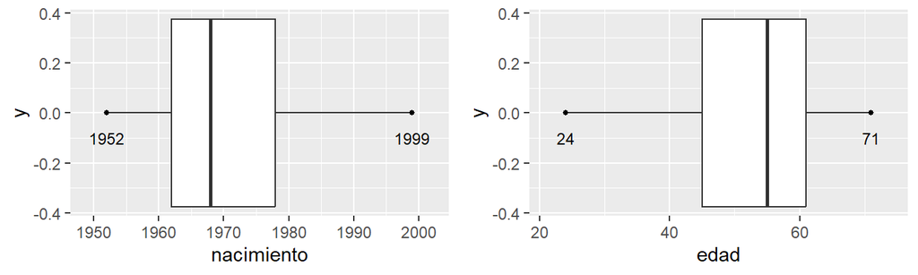

```r
gridExtra::grid.arrange(p1,p5 , nrow=1,ncol=2)
```

[output not shown]

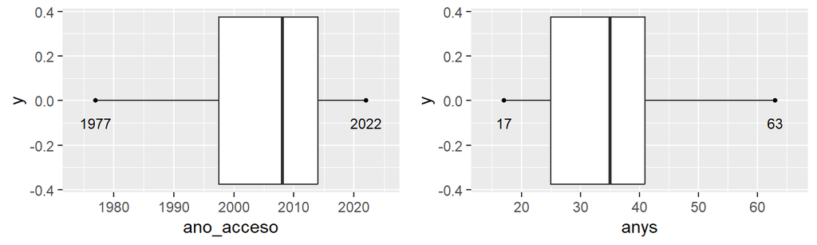

```r
gridExtra::grid.arrange(p2,p4 , nrow=1,ncol=2)
bdf[which(bdf$a.fun<1900),which(colnames(bdf)=="mot_duen")]
```

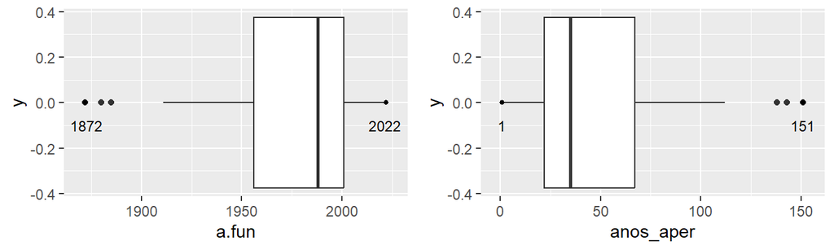

```r
gridExtra::grid.arrange(p3,p8 , nrow=1,ncol=2)
```

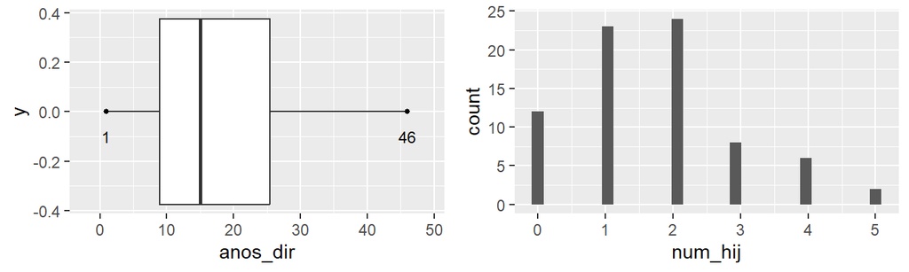

```r
gridExtra::grid.arrange(p6,p7 , nrow=1,ncol=2)
```

## Valores perdidos

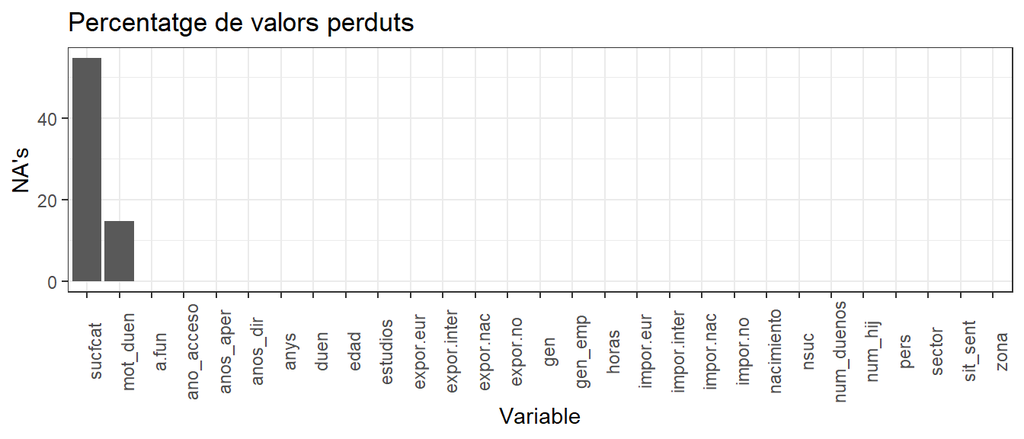

```r
require(tidyverse)
data_long <- bdf%>%gather(key = "variable", value = "valor")
data_long %>%
group_by(variable) %>%
dplyr::summarize(porcentaje_NA = 100 * sum(is.na(valor)) / length(valor)) %>%
ggplot(aes(x = reorder(variable, desc(porcentaje_NA)), y = porcentaje_NA)) +
geom_col() +
labs(title = "Percentatge de valors perduts",
x = "Variable", y = "NA's") +
theme_bw()+ theme(axis.text.x=element_text(angle=90))
```

Tanmateix, a tots els valors buits que s’hi troben a sucfcat els hi afegirem el valor “No” corresponent a tenir empreses fora de Catalunya i a “mot_duen” permetrem que les dades continuin tenint els “NA’s”.

```r
bdf$sucfcat[(is.na(bdf$sucfcat))] <- "No"
```

# Descriptiva de les dades

Natalia! Los quesito son bien o no?

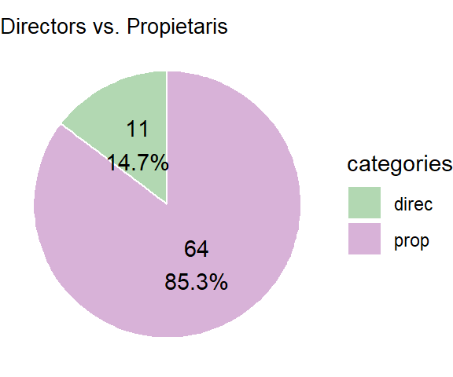

```r
tab <- ifelse(bdf$duen == 0, "direc", "prop")
counts <- table(tab)
per <- round(counts/sum(counts) * 100, 1)
df <- data.frame(categories = names(counts), counts = as.numeric(counts), per = per)

ggplot(data = df, aes(x = "", y = counts, fill = categories)) +
  geom_bar(width = 1, stat = "identity", color = "white") +
  coord_polar(theta = "y") +
  theme_void() +
  scale_fill_manual(values = c("direc" = "#b2d8b2", "prop" = "#d8b2d8")) +
  geom_text(aes(label = paste0(counts, "\n", per, "%")),
            position = position_stack(vjust = 0.5)) +
  ggtitle("Directors vs. Propietaris")+
  theme(plot.title = element_text(size=10))
```

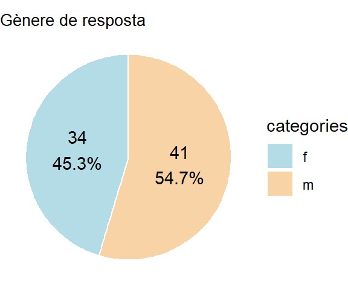

```r
counts <- table(bdf$gen)
per <- round(counts/sum(counts) * 100, 1)
df <- data.frame(categories = names(counts), counts = as.numeric(counts), per = per)

ggplot(data = df, aes(x = "", y = counts, fill = categories)) +
  geom_bar(width = 1, stat = "identity", color = "white") +
  coord_polar(theta = "y") +
  theme_void() +
  scale_fill_manual(values = c("f" = "#B4DCE7", "m" = "#F8D3A5")) +
  geom_text(aes(label = paste0(counts, "\n", per, "%")),
            position = position_stack(vjust = 0.5))+
  ggtitle("Gènere de resposta")+
  theme(plot.title = element_text(size=10))
```

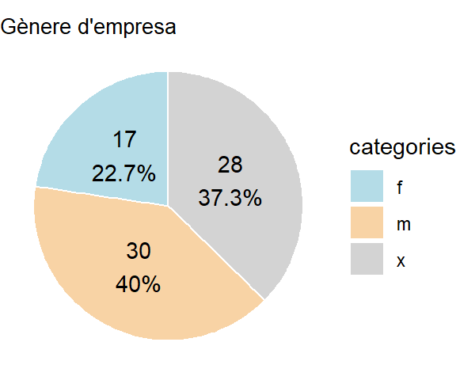

```r
counts <- table(bdf$gen_emp)
per <- round(counts/sum(counts) * 100, 1)
df <- data.frame(categories = names(counts), counts = as.numeric(counts), per = per)

ggplot(data = df, aes(x = "", y = counts, fill = categories)) +
  geom_bar(width = 1, stat = "identity", color = "white") +
  coord_polar(theta = "y") +
  theme_void() +
  scale_fill_manual(values = c("f" = "#B4DCE7", "m" = "#F8D3A5", "x" = "#D3D3D3")) +
  geom_text(aes(label = paste0(counts, "\n", per, "%")),
            position = position_stack(vjust = 0.5))+
  ggtitle("Gènere d'empresa")+
  theme(plot.title = element_text(size=10))
```

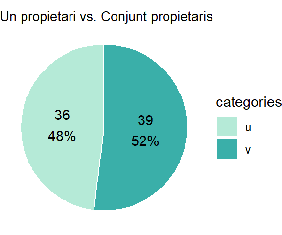

```r
counts <- table(bdf$num_duenos)
per <- round(counts/sum(counts) * 100, 1)
df <- data.frame(categories = names(counts), counts = as.numeric(counts), per = per)

ggplot(data = df, aes(x = "", y = counts, fill = categories)) +
  geom_bar(width = 1, stat = "identity", color = "white") +
  coord_polar(theta = "y") +
  theme_void() +
  scale_fill_manual(values = c("u" = "#B5EAD7", "v" = "#3AAFA9")) +
  geom_text(aes(label = paste0(counts, "\n", per, "%")),
            position = position_stack(vjust = 0.5))+
  ggtitle("Un propietari vs. Conjunt propietaris")+
  theme(plot.title = element_text(size=10))
```

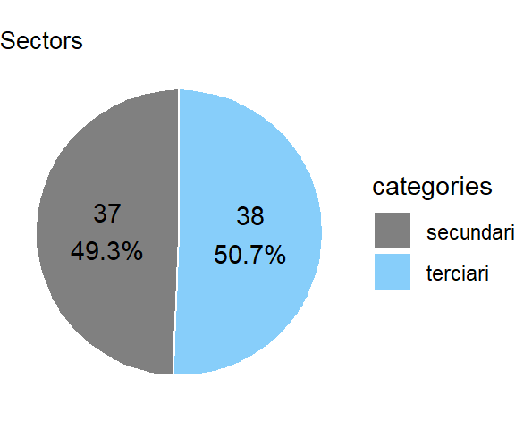

```r
counts <- table(bdf$sector)
names(counts) <- c("secundari", "terciari")
per <- round(counts/sum(counts) * 100, 1)
df <- data.frame(categories = names(counts), counts = as.numeric(counts), per = per)

ggplot(data = df, aes(x = "", y = counts, fill = categories)) +
  geom_bar(width = 1, stat = "identity", color = "white") +
  coord_polar(theta = "y") +
  theme_void() +
  scale_fill_manual(values = c("secundari" = "#808080", "terciari" = "#87CEFA")) +
  geom_text(aes(label = paste0(counts, "\n", per, "%")),
            position = position_stack(vjust = 0.5))+
  ggtitle("Sectors")+
  theme(plot.title = element_text(size=10))
```

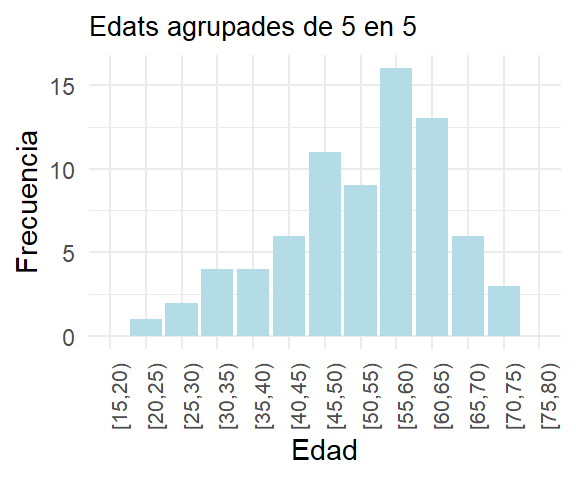

```r
grupos_edad <- cut(bdf$edad, breaks=seq(15,85, by=5))
df <- data.frame(bdf$edad)
df$grupos_edad <- cut(df$bdf.edad, seq(15, 80, by = 5), right = FALSE)
freq_edad <- table(df$grupos_edad)
df_freq_edad <- data.frame(grupos_edad = as.character(names(freq_edad)),
                           freq = as.numeric(freq_edad))

ggplot(data = df_freq_edad, aes(x = grupos_edad, y = freq)) +
  geom_bar(stat = "identity", fill = "#B4DCE7") +
  labs(x = "Edad", y = "Frecuencia") +
  ggtitle("Edats agrupades de 5 en 5") +
  theme_minimal()+
  theme(axis.text.x = element_text(size = 8, angle = 90, hjust = 1),
        plot.title = element_text(size = 10))
```

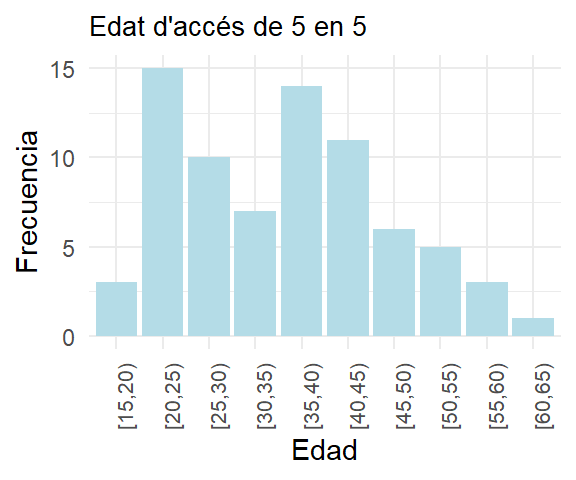

```r
grupos_edad <- cut(bdf$anys, breaks=seq(15,65, by=5))
df <- data.frame(bdf$anys)
df$grupos_edad <- cut(df$bdf.anys, seq(15, 65, by = 5), right = FALSE)
freq_edad <- table(df$grupos_edad)
df_freq_edad <- data.frame(grupos_edad = as.character(names(freq_edad)),
                           freq = as.numeric(freq_edad))

ggplot(data = df_freq_edad, aes(x = grupos_edad, y = freq)) +
  geom_bar(stat = "identity", fill = "#B4DCE7") +
  labs(x = "Edad", y = "Frecuencia") +
  ggtitle("Edat d'accés de 5 en 5") +
  theme_minimal()+
  theme(axis.text.x = element_text(size = 8, angle = 90, hjust = 1),
        plot.title = element_text(size = 10))
```

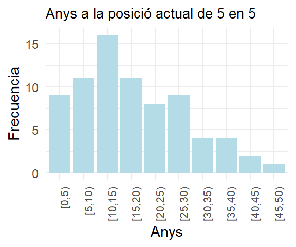

```r
grupos_edad <- cut(bdf$anos_dir, breaks=seq(0,50, by=5))
df <- data.frame(bdf$anos_dir)
df$grupos_edad <- cut(df$bdf.anos_dir, seq(0, 50, by = 5), right = FALSE)

orden_niveles <- c("[0,5)", "[5,10)", "[10,15)", "[15,20)", "[20,25)", "[25,30)",
                   "[30,35)", "[35,40)", "[40,45)", "[45,50)")
df$grupos_edad <- factor(df$grupos_edad, levels = orden_niveles)

freq_edad <- table(df$grupos_edad)
df_freq_edad <- data.frame(grupos_edad = as.character(names(freq_edad)),
                           freq = as.numeric(freq_edad))

ggplot(data = df_freq_edad, aes(x = grupos_edad, y = freq)) +
  geom_bar(stat = "identity", fill = "#B4DCE7") +
  labs(x = "Anys", y = "Frecuencia") +
  ggtitle("Anys a la posició actual de 5 en 5") +
  theme_minimal() +
  scale_x_discrete(limits = orden_niveles) +
  theme(axis.text.x = element_text(size = 8, angle = 90, hjust = 1),
        plot.title = element_text(size = 10))
```

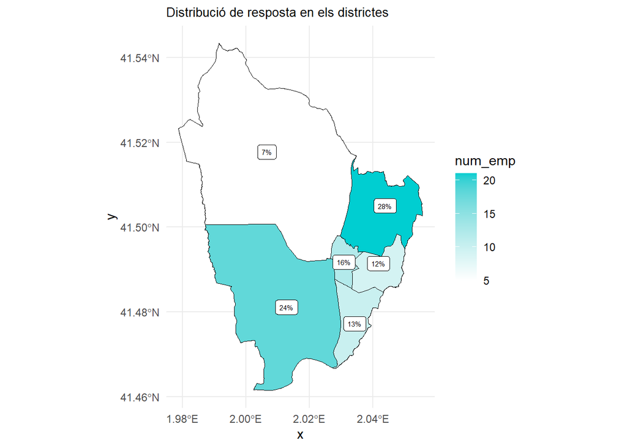

```r
library(sf)
library(ggplot2)
library(rnaturalearth)

#cargamos archivo
rubi <- st_read("distadmin.geojson")
rubi$id <- paste0(rubi$nomadmin)

#igualamos valores de rubi$nomadmin y bdf$zona
correspondencia <- c("C" = "Centre", "E" = "Est", "N" = "Nord", "NO" = "Nord Oest",
                     "S" = "Sud", "SO" = "Sud Oest")
zon <- bdf$zona
zon <- correspondencia[zon]

#hacemos un data.frame con la tabla obtenida
num_emp <- as.data.frame(table(zon))
colnames(num_emp) <- c("nomadmin", "num_emp")

#mezclamos los resultados del data.frame con el mapa
rubi_map <- merge(rubi, num_emp, by = "nomadmin", all.x = TRUE)

rubi_map$porcentaje_respuestas <- (rubi_map$num_emp / sum(rubi_map$num_emp)) * 100
# Visualizamos el mapa
ggplot(rubi_map) +
  geom_sf(aes(fill = num_emp), color = "black") +
  scale_fill_gradient(low = "white", high = "#00CED1") +
  geom_sf_label(aes(label = paste0(round(porcentaje_respuestas), "%")), color = "black",
                size = 2, nudge_x = 0, nudge_y = 0) +
  ggtitle("Distribució de resposta en els districtes") +
  theme_minimal()+
  theme(plot.title = element_text(size=10))
```

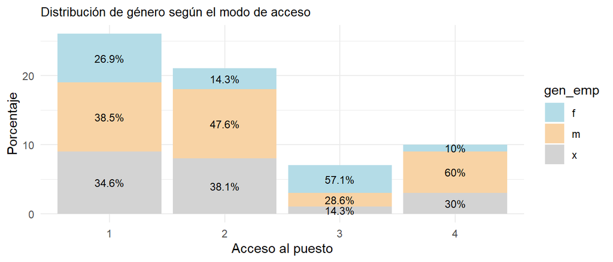

```r
# Calcular los porcentajes
porcentajes <- bdf %>%
  filter(mot_duen %in% c(1, 2, 3, 4)) %>%
  group_by(mot_duen, gen_emp) %>%
  summarise(freq = sum(!is.na(gen_emp))) %>%
  group_by(mot_duen) %>%
  mutate(porcentaje = freq / sum(freq) * 100) %>%
  invisible()


# Crear el gráfico de columna apilada
suppressMessages({
  ggplot(porcentajes, aes(x = mot_duen, y = freq, fill = gen_emp)) +
    geom_bar(stat = "identity", position = "stack") +
    geom_text(aes(label = paste0(round(porcentaje, 1), "%"),
                  y = freq,
                  group = gen_emp),
              position = position_stack(vjust = 0.5),
              size = 3,
              color = "black") +
    scale_y_continuous(labels = scales::comma) +
    labs(title = "Distribución de género según el modo de acceso",
         x = "Acceso al puesto",
         y = "Porcentaje") +
    scale_fill_manual(values = c("f" = "#B4DCE7", "m" = "#F8D3A5", "x" = "#D3D3D3")) +
    theme_minimal()+
  theme(plot.title = element_text(size=10))
})
```

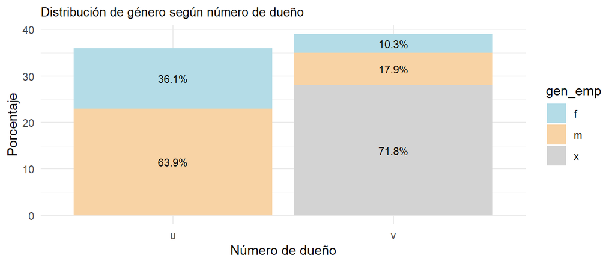

```r
porcentajes <- bdf %>%
  filter(num_duenos %in% c("u", "v")) %>%
  group_by(num_duenos, gen_emp) %>%
  summarise(freq = sum(!is.na(gen_emp))) %>%
  group_by(num_duenos) %>%
  mutate(porcentaje = freq / sum(freq) * 100) %>%
  invisible()

suppressMessages({
  ggplot(porcentajes, aes(x = num_duenos, y = freq, fill = gen_emp)) +
    geom_bar(stat = "identity", position = "stack") +
    geom_text(aes(label = paste0(round(porcentaje, 1), "%"),
                  y = freq,
                  group = gen_emp),
              position = position_stack(vjust = 0.5),
              size = 3,
              color = "black") +
    scale_y_continuous(labels = scales::comma) +
    labs(title = "Distribución de género según número de dueño",
         x = "Número de dueño",
         y = "Porcentaje") +
    scale_fill_manual(values = c("f" = "#B4DCE7", "m" = "#F8D3A5", "x" = "#D3D3D3")) +
    theme_minimal()+
  theme(plot.title = element_text(size=10))
})
```

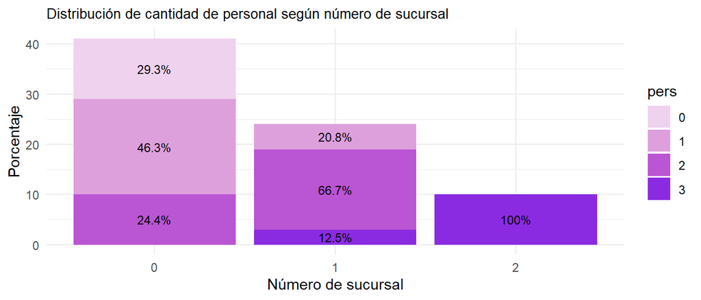

```r
porcentajes <- bdf %>%
  filter(nsuc %in% c("0", "1", "2")) %>%
  group_by(nsuc, pers) %>%
  summarise(freq = sum(!is.na(pers))) %>%
  group_by(nsuc) %>%
  mutate(porcentaje = freq / sum(freq) * 100) %>%
  invisible()

suppressMessages({
  ggplot(porcentajes, aes(x = nsuc, y = freq, fill = pers)) +
    geom_bar(stat = "identity", position = "stack") +
    geom_text(aes(label = paste0(round(porcentaje, 1), "%"),
                  y = freq,
                  group = pers),
              position = position_stack(vjust = 0.5),
              size = 3,
              color = "black") +
    scale_y_continuous(labels = scales::comma) +
    labs(title = "Distribución de cantidad de personal según número de sucursal",
         x = "Número de sucursal",
         y = "Porcentaje") +
    scale_fill_manual(values = c("0" = "#EED2EE", "1" = "#DDA0DD",
                                 "2" = "#BA55D3", "3" = "#8A2BE2")) +
    theme_minimal() +
    theme(plot.title = element_text(size = 10))
})
```

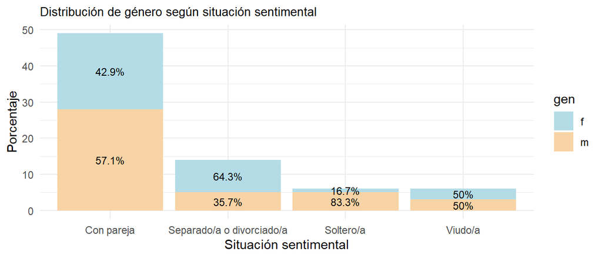

```r
porcentajes <- bdf %>%
  filter(sit_sent %in% c("Con pareja", "Separado/a o divorciado/a",
                         "Soltero/a", "Viudo/a")) %>%
  group_by(sit_sent, gen) %>%
  summarise(freq = sum(!is.na(gen))) %>%
  group_by(sit_sent) %>%
  mutate(porcentaje = freq / sum(freq) * 100) %>%
  invisible()

suppressMessages({
  ggplot(porcentajes, aes(x = sit_sent, y = freq, fill = gen)) +
    geom_bar(stat = "identity", position = "stack") +
    geom_text(aes(label = paste0(round(porcentaje, 1), "%"),
                  y = freq,
                  group = gen),
              position = position_stack(vjust = 0.5),
              size = 3,
              color = "black") +
    scale_y_continuous(labels = scales::comma) +
    labs(title = "Distribución de género según situación sentimental",
         x = "Situación sentimental",
         y = "Porcentaje") +
    scale_fill_manual(values = c("f" = "#B4DCE7", "m" = "#F8D3A5")) +
    theme_minimal()+
  theme(plot.title = element_text(size=10))
})
```

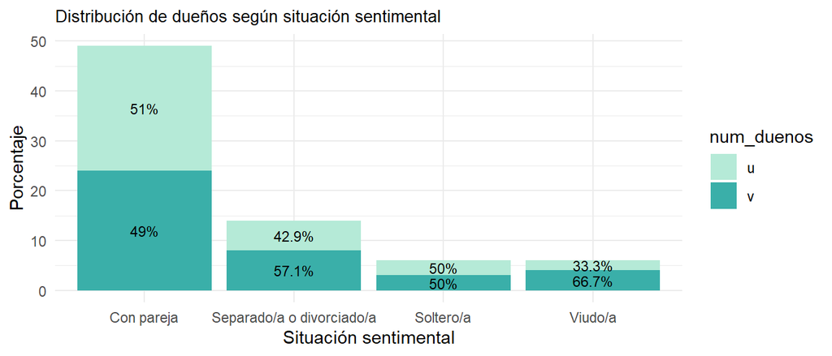

```r
porcentajes <- bdf %>%
  filter(sit_sent %in% c("Con pareja", "Separado/a o divorciado/a",
                         "Soltero/a", "Viudo/a")) %>%
  group_by(sit_sent, num_duenos) %>%
  summarise(freq = sum(!is.na(num_duenos))) %>%
  group_by(sit_sent) %>%
  mutate(porcentaje = freq / sum(freq) * 100) %>%
  invisible()

suppressMessages({
  ggplot(porcentajes, aes(x = sit_sent, y = freq, fill = num_duenos)) +
    geom_bar(stat = "identity", position = "stack") +
    geom_text(aes(label = paste0(round(porcentaje, 1), "%"),
                  y = freq,
                  group = num_duenos),
              position = position_stack(vjust = 0.5),
              size = 3,
              color = "black") +
    scale_y_continuous(labels = scales::comma) +
    labs(title = "Distribución de dueños según situación sentimental",
         x = "Situación sentimental",
         y = "Porcentaje") +
    scale_fill_manual(values = c("u" = "#B5EAD7", "v" = "#3AAFA9")) +
    theme_minimal()+
  theme(plot.title = element_text(size=10))
})
```

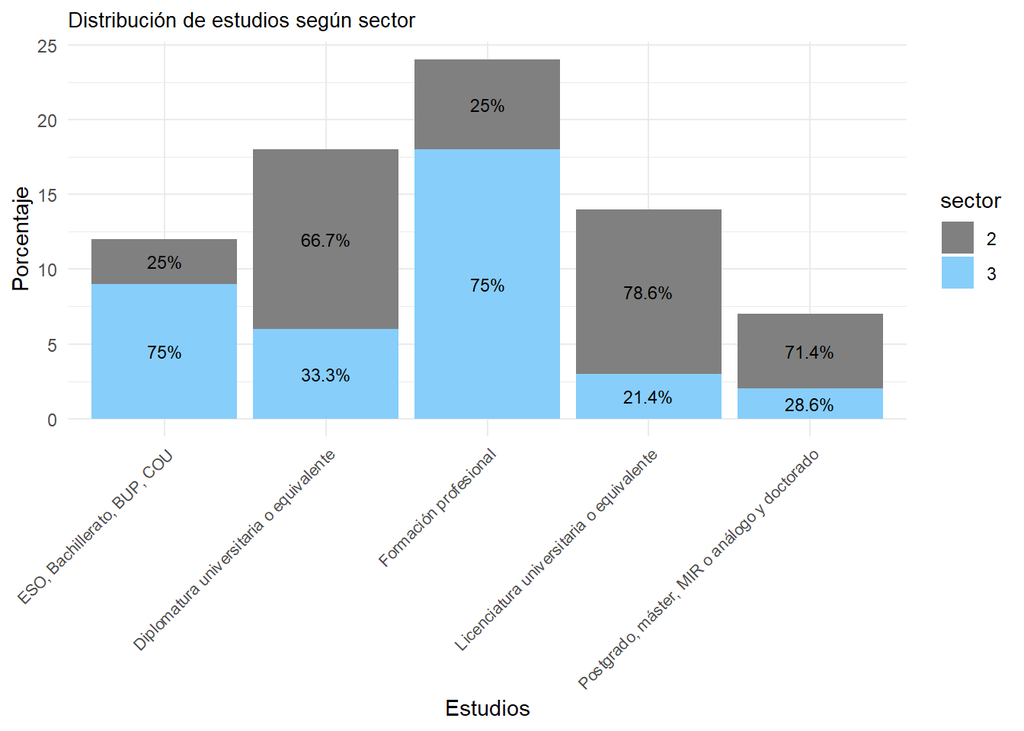

```r
porcentajes <- bdf %>%
  filter(estudios %in% c("ESO, Bachillerato, BUP, COU",
                         "Diplomatura universitaria o equivalente",
                         "Formación profesional",
                         "Licenciatura universitaria o equivalente",
                         "Postgrado, máster, MIR o análogo y doctorado")) %>%
  group_by(estudios, sector) %>%
  summarise(freq = sum(!is.na(sector))) %>%
  group_by(estudios) %>%
  mutate(porcentaje = freq / sum(freq) * 100) %>%
  invisible()

suppressMessages({
  ggplot(porcentajes, aes(x = estudios, y = freq, fill = sector)) +
    geom_bar(stat = "identity", position = "stack") +
    geom_text(aes(label = paste0(round(porcentaje, 1), "%"),
                  y = freq,
                  group = sector),
              position = position_stack(vjust = 0.5),
              size = 3,
              color = "black") +
    scale_y_continuous(labels = scales::comma) +
    labs(title = "Distribución de estudios según sector",
         x = "Estudios",
         y = "Porcentaje") +
    scale_fill_manual(values = c("2" = "#808080", "3" = "#87CEFA")) +
    theme_minimal()+
  theme(plot.title = element_text(size=10),
        axis.text.x = element_text(size = 8, angle = 45, hjust = 1))
})
```

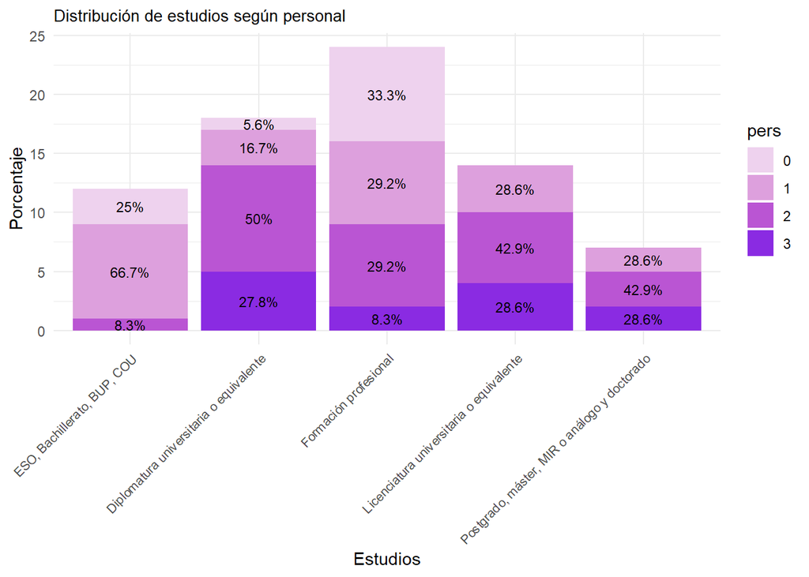

```r
porcentajes <- bdf %>%
  filter(estudios %in% c("ESO, Bachillerato, BUP, COU",
                         "Diplomatura universitaria o equivalente",
                         "Formación profesional",
                         "Licenciatura universitaria o equivalente",
                         "Postgrado, máster, MIR o análogo y doctorado")) %>%
  group_by(estudios, pers) %>%
  summarise(freq = sum(!is.na(pers))) %>%
  group_by(estudios) %>%
  mutate(porcentaje = freq / sum(freq) * 100) %>%
  invisible()

suppressMessages({
  ggplot(porcentajes, aes(x = estudios, y = freq, fill = pers)) +
    geom_bar(stat = "identity", position = "stack") +
    geom_text(aes(label = paste0(round(porcentaje, 1), "%"),
                  y = freq,
                  group = pers),
              position = position_stack(vjust = 0.5),
              size = 3,
              color = "black") +
    scale_y_continuous(labels = scales::comma) +
    labs(title = "Distribución de estudios según personal",
         x = "Estudios",
         y = "Porcentaje") +
    scale_fill_manual(values = c("0" = "#EED2EE", "1" = "#DDA0DD",
                                 "2" = "#BA55D3", "3" = "#8A2BE2")) +
    theme_minimal()+
  theme(plot.title = element_text(size=10),
        axis.text.x = element_text(size = 8, angle = 45, hjust = 1))
})
```

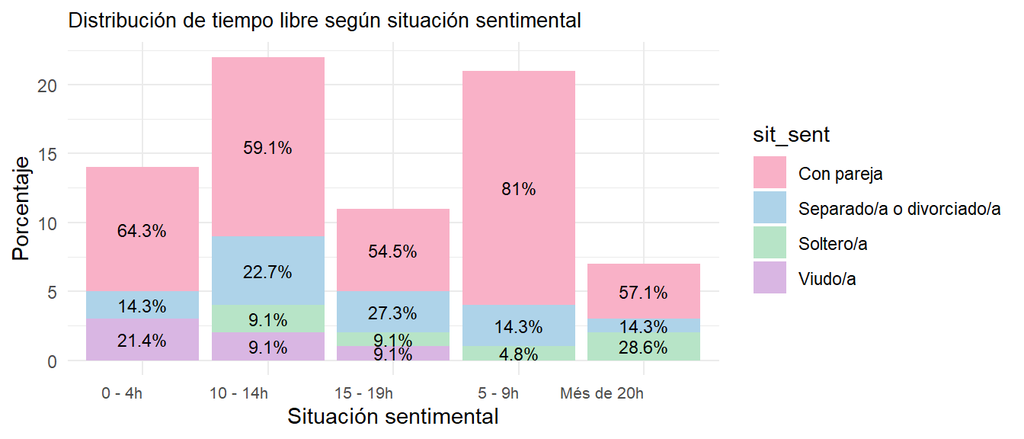

```r
porcentajes <- bdf %>%
  filter(horas %in% c("0 - 4h", "5 - 9h",
                         "10 - 14h", "15 - 19h",
                         "Més de 20h")) %>%
  group_by(horas, sit_sent) %>%
  summarise(freq = sum(!is.na(sit_sent))) %>%
  group_by(horas) %>%
  mutate(porcentaje = freq / sum(freq) * 100) %>%
  invisible()

suppressMessages({
  ggplot(porcentajes, aes(x = horas, y = freq, fill = sit_sent)) +
    geom_bar(stat = "identity", position = "stack") +
    geom_text(aes(label = paste0(round(porcentaje, 1), "%"),
                  y = freq,
                  group = sit_sent),
              position = position_stack(vjust = 0.5),
              size = 3,
              color = "black") +
    scale_y_continuous(labels = scales::comma) +
    labs(title = "Distribución de tiempo libre según situación sentimental",
         x = "Situación sentimental",
         y = "Porcentaje") +
    scale_fill_manual(values = c("Con pareja" = "#F9B1C7",
                         "Separado/a o divorciado/a" = "#AED3E9",
                         "Soltero/a" = "#B7E4C7",
                         "Viudo/a" = "#D9B6E3")) +
    theme_minimal()+
  theme(plot.title = element_text(size=10),
        axis.text.x = element_text(size = 8,  hjust = 1))
})
```

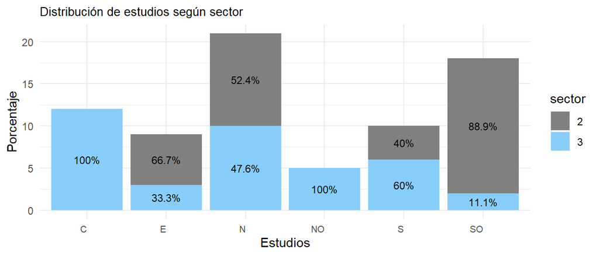

```r
porcentajes <- bdf %>%
  filter(zona %in% c("NO", "N", "C", "E", "S", "SO")) %>%
  group_by(zona, sector) %>%
  summarise(freq = sum(!is.na(sector))) %>%
  group_by(zona) %>%
  mutate(porcentaje = freq / sum(freq) * 100) %>%
  invisible()

suppressMessages({
  ggplot(porcentajes, aes(x = zona, y = freq, fill = sector)) +
    geom_bar(stat = "identity", position = "stack") +
    geom_text(aes(label = paste0(round(porcentaje, 1), "%"),
                  y = freq,
                  group = sector),
              position = position_stack(vjust = 0.5),
              size = 3,
              color = "black") +
    scale_y_continuous(labels = scales::comma) +
    labs(title = "Distribución de estudios según sector",
         x = "Estudios",
         y = "Porcentaje") +
    scale_fill_manual(values = c("2" = "#808080", "3" = "#87CEFA")) +
    theme_minimal()+
  theme(plot.title = element_text(size=10),
        axis.text.x = element_text(size = 8, hjust = 1))
})
```

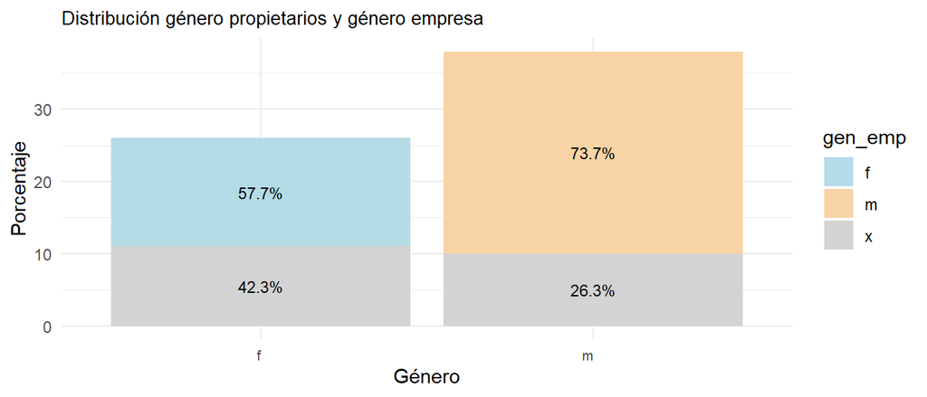

```r
x <- which(bdf$duen==1)
y <- which(bdf$duen==2)
bdfprop <- bdf[c(x,y),]

porcentajes <- bdfprop %>%
  filter(gen %in% c("f", "m")) %>%
  group_by(gen, gen_emp) %>%
  summarise(freq = sum(!is.na(gen_emp))) %>%
  group_by(gen) %>%
  mutate(porcentaje = freq / sum(freq) * 100) %>%
  invisible()

suppressMessages({
  ggplot(porcentajes, aes(x = gen, y = freq, fill = gen_emp)) +
    geom_bar(stat = "identity", position = "stack") +
    geom_text(aes(label = paste0(round(porcentaje, 1), "%")),
              position = position_stack(vjust = 0.5),
              size = 3,
              color = "black") +
    scale_y_continuous(labels = scales::comma) +
    labs(title = "Distribución género propietarios y género empresa",
         x = "Género",
         y = "Porcentaje") +
    scale_fill_manual(values = c("f" = "#B4DCE7", "m" = "#F8D3A5", "x" = "#D3D3D3")) +
    theme_minimal() +
    theme(plot.title = element_text(size = 10),
          axis.text.x = element_text(size = 8, hjust = 1))
})
```

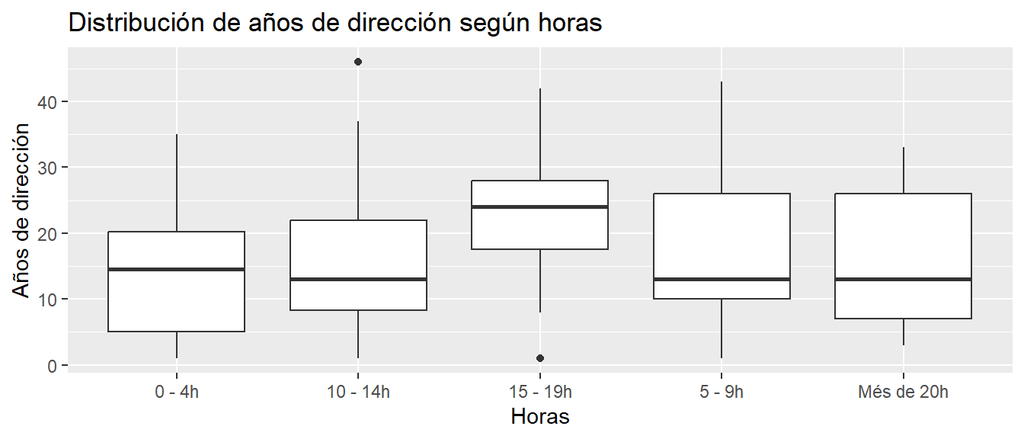

```r
ggplot(bdf, aes(x = horas, y = anos_dir)) +
  geom_boxplot() +
  labs(title = "Distribución de años de dirección según horas",
       x = "Horas",
       y = "Años de dirección")
```

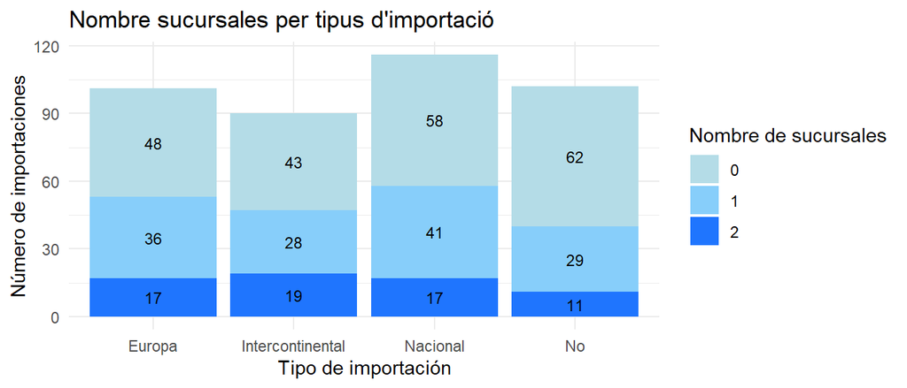

```r
dades_sucursal <- aggregate(cbind(impor.nac, impor.eur, impor.inter, impor.no) ~ nsuc,
                            data = bdf, FUN = sum)

dades_sucursal_llarg <- tidyr::pivot_longer(dades_sucursal,
                                            cols = c("impor.nac", "impor.eur",
                                                     "impor.inter", "impor.no"),
                                            names_to = "Variable", values_to = "1s")

ggplot(dades_sucursal_llarg, aes(x = Variable, y = `1s`, fill = factor(nsuc))) +
  geom_bar(stat = "identity", position = "stack") +
  scale_x_discrete(labels = c("Europa", "Intercontinental", "Nacional", "No")) +
  labs(x = "Tipo de importación", y = "Número de importaciones",
       fill = "Nombre de sucursales") +
  ggtitle("Nombre sucursales per tipus d'importació") +
  geom_text(aes(label = format(`1s`, big.mark = ".", decimal.mark = ",",
                               scientific = FALSE)), size = 3,
            position = position_stack(vjust = 0.5)) +
  scale_fill_manual(values = c("0" = "#B4DCE7", "1" = "#87CEFA", "2" = "#1F75FE")) +
  theme_minimal()
```

* Exportació vs Nombre sucursal

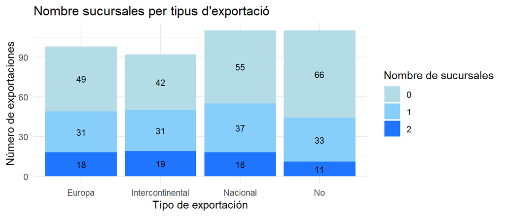

```r
dades_sucursal <- aggregate(cbind(expor.nac, expor.eur, expor.inter, expor.no) ~ nsuc,
                            data = bdf, FUN = sum)

dades_sucursal_llarg <- tidyr::pivot_longer(dades_sucursal,
                                            cols = c("expor.nac", "expor.eur",
                                                     "expor.inter", "expor.no"),
                                            names_to = "Variable", values_to = "1s")

ggplot(dades_sucursal_llarg, aes(x = Variable, y = `1s`, fill = factor(nsuc))) +
  geom_bar(stat = "identity", position = "stack") +
  scale_x_discrete(labels = c("Europa", "Intercontinental", "Nacional", "No")) +
  labs(x = "Tipo de exportación", y = "Número de exportaciones",
       fill = "Nombre de sucursales") +
  ggtitle("Nombre sucursales per tipus d'exportació") +
  geom_text(aes(label = format(`1s`, big.mark = ".", decimal.mark = ",",
                               scientific = FALSE)), size = 3,
            position = position_stack(vjust = 0.5))+
  scale_fill_manual(values = c("0" = "#B4DCE7", "1" = "#87CEFA", "2" = "#1F75FE")) +
  theme_minimal()
```

```r
bdffem <- bdf[bdf$gen_emp=="f",]
bdfmas <- bdf[bdf$gen_emp=="m",]
bdfmix <- bdf[bdf$gen_emp=="x",]

bdfpropfem <- bdf[bdfprop$gen_emp=="f",]
bdfpropmas <- bdf[bdfprop$gen_emp=="m",]
bdfpropmix <- bdf[bdfprop$gen_emp=="x",]
```

```r
(smod <- summary(glm(sector~anys, data=bdfprop, family="binomial")))
(smodf <- summary(glm(sector~anys, data=bdfpropfem, family="binomial")))
(smodm <- summary(glm(sector~anys, data=bdfpropmas, family="binomial")))
(smodx <- summary(glm(sector~anys, data=bdfpropmix, family="binomial")))
```

```
##
## Call:
## glm(formula = sector ~ anys, family = "binomial", data = bdfprop)
##
## Deviance Residuals:
##     Min       1Q   Median       3Q      Max
## -1.6518  -1.2153   0.7839   1.0161   1.4877
##
## Coefficients:
##             Estimate Std. Error z value Pr(>|z|)
## (Intercept)  2.00297    0.89111   2.248   0.0246 *
## anys        -0.04669    0.02427  -1.924   0.0544 .
## ---
## Signif. codes:  0 '***' 0.001 '**' 0.01 '*' 0.05 '.' 0.1 ' ' 1
##
## (Dispersion parameter for binomial family taken to be 1)
##
##     Null deviance: 86.459  on 63  degrees of freedom
## Residual deviance: 82.517  on 62  degrees of freedom
## AIC: 86.517
##
## Number of Fisher Scoring iterations: 4
##
##
## Call:
## glm(formula = sector ~ anys, family = "binomial", data = bdfpropfem)
##
## Deviance Residuals:
##      Min        1Q    Median        3Q       Max
## -2.40320   0.04117   0.36061   0.83280   0.97733
##
## Coefficients:
##             Estimate Std. Error z value Pr(>|z|)
## (Intercept)  5.81990    2.84475   2.046   0.0408 *
## anys        -0.12998    0.07287  -1.784   0.0745 .
## ---
## Signif. codes:  0 '***' 0.001 '**' 0.01 '*' 0.05 '.' 0.1 ' ' 1
##
## (Dispersion parameter for binomial family taken to be 1)
##
```

[output cut: 32 more lines]

```
##     Min       1Q   Median       3Q      Max
## -1.1697  -0.8173  -0.5225  -0.1985   1.9507
##
## Coefficients:
##             Estimate Std. Error z value Pr(>|z|)
## (Intercept)  1.79559    2.04940   0.876    0.381
## anys        -0.09068    0.06523  -1.390    0.164
##
## (Dispersion parameter for binomial family taken to be 1)
##
##     Null deviance: 23.053  on 20  degrees of freedom
## Residual deviance: 20.407  on 19  degrees of freedom
## AIC: 24.407
##
## Number of Fisher Scoring iterations: 5
```

En otras palabras, el coeficiente negativo sugiere que a medida que aumenta la variable “anys”, la probabilidad logarítmica de pertenecer a la categoría “terciario” en lugar de la categoría “secundario” disminuye. Sin embargo, para obtener una interpretación más precisa y comprensiva, es importante recordar que los resultados de la regresión logística binaria se expresan en términos de log odds y no de probabilidades directas.

Si deseas obtener una interpretación más intuitiva en términos de probabilidades, puedes aplicar la transformación inversa utilizando la función logística. La probabilidad de pertenecer a la categoría “terciario” en lugar de la categoría “secundario” se puede calcular de la siguiente manera:

Probabilidad = exp(coeficiente) / (1 + exp(coeficiente))

Donde “coeficiente” es el valor del coeficiente estimado para la variable predictora “anys”. Sin embargo, ten en cuenta que esta interpretación en términos de probabilidades puede estar sujeta a ciertas suposiciones y condiciones dentro del modelo.

```r
# NATALIA
smod <- summary(polr(nsuc ~ anys, data = bdfprop))
smodf <- summary(glm(sector~anys, data=bdfpropfem, family="binomial"))
smodm <- summary(glm(sector~anys, data=bdfpropmas, family="binomial"))
smodx <- summary(glm(sector~anys, data=bdfpropmix, family="binomial"))
```

```r
(smod <- summary(lm(num_hij ~ nsuc + pers, data = bdf)))
(smodf <- summary(lm(num_hij ~ nsuc + pers, data = bdffem)))
(smodm <- summary(lm(num_hij ~ nsuc + pers, data = bdfmas)))
(smodx <- summary(lm(num_hij ~ nsuc + pers, data = bdfmix)))
```

```
##
## Call:
## lm(formula = num_hij ~ nsuc + pers, data = bdf)
##
## Residuals:
##      Min       1Q   Median       3Q      Max
## -1.88906 -0.88906  0.04501  0.51125  3.04501
##
## Coefficients:
##             Estimate Std. Error t value Pr(>|t|)
## (Intercept)   1.0833     0.3554   3.048  0.00326 **
## nsuc1         0.3116     0.3871   0.805  0.42370
## nsuc2         1.0449     0.8981   1.163  0.24866
## pers1         0.5601     0.4427   1.265  0.21003
## pers2         0.4942     0.4913   1.006  0.31799
## pers3         0.2718     0.8840   0.307  0.75943
## ---
## Signif. codes:  0 '***' 0.001 '**' 0.01 '*' 0.05 '.' 0.1 ' ' 1
##
## Residual standard error: 1.231 on 69 degrees of freedom
## Multiple R-squared:  0.0916, Adjusted R-squared:  0.02577
## F-statistic: 1.391 on 5 and 69 DF,  p-value: 0.2383
##
##
## Call:
## lm(formula = num_hij ~ nsuc + pers, data = bdffem)
##
## Residuals:
##     Min      1Q  Median      3Q     Max
## -1.2000 -0.6667  0.1429  0.5000  1.1429
##
## Coefficients:
##             Estimate Std. Error t value Pr(>|t|)
## (Intercept)   0.8571     0.3114   2.753   0.0165 *
## nsuc1        -1.3000     0.6893  -1.886   0.0818 .
## pers1        -0.1905     0.5685  -0.335   0.7429
## pers2         1.6429     0.6606   2.487   0.0272 *
## ---
## Signif. codes:  0 '***' 0.001 '**' 0.01 '*' 0.05 '.' 0.1 ' ' 1
##
```

[output cut: 34 more lines]

```
##
## Coefficients:
##             Estimate Std. Error t value Pr(>|t|)
## (Intercept)   2.5000     0.7838   3.190  0.00423 **
## nsuc1         1.0508     0.5476   1.919  0.06806 .
## nsuc2         1.3842     0.9562   1.448  0.16181
## pers1        -1.1441     0.9001  -1.271  0.21697
## pers2        -1.1949     0.9184  -1.301  0.20668
## pers3        -1.8842     1.1506  -1.638  0.11573
## ---
## Signif. codes:  0 '***' 0.001 '**' 0.01 '*' 0.05 '.' 0.1 ' ' 1
##
## Residual standard error: 1.108 on 22 degrees of freedom
## Multiple R-squared:  0.1728, Adjusted R-squared:  -0.01518
## F-statistic: 0.9193 on 5 and 22 DF,  p-value: 0.487
```

```r
bdfprop <- bdf[c(which(bdf$duen==1), which(bdf$duen==2)), c(4,11,12,3,5,6,25,26,27,28)]
bdfpropfem <- bdfprop[which(bdfprop$gen_emp=="f"),-1]
bdfpropmas <- bdfprop[which(bdfprop$gen_emp=="m"),-1]
bdfpropmix <- bdfprop[which(bdfprop$gen_emp=="x"),-1]

(smod <- summary(glm(sector ~ anys + num_hij + sit_sent + estudios,
                     data = bdfprop, family="binomial")))
(smodf <- summary(glm(sector ~ anys + num_hij + sit_sent + estudios,
                      data = bdfpropfem, family="binomial")))
(smodm <- summary(glm(sector ~ anys + num_hij + sit_sent + estudios,
                      data = bdfpropmas, family="binomial")))
(smodx <- summary(glm(sector ~ anys + num_hij + sit_sent + estudios,
                      data = bdfpropmix, family="binomial")))
```

```
##
## Call:
## glm(formula = sector ~ anys + num_hij + sit_sent + estudios,
##     family = "binomial", data = bdfprop)
##
## Deviance Residuals:
##     Min       1Q   Median       3Q      Max
## -2.0246  -0.6085   0.4651   0.7733   1.9443
##
## Coefficients:
##                                                      Estimate Std. Error
## (Intercept)                                           3.15775    1.42570
## anys                                                 -0.03516    0.02921
## num_hij                                              -0.36701    0.28112
## sit_sentSeparado/a o divorciado/a                    -0.58549    0.92102
## sit_sentSoltero/a                                     2.33234    1.60469
## sit_sentViudo/a                                      -0.35666    1.33283
## estudiosDiplomatura universitaria o equivalente      -1.52532    0.99626
## estudiosFormación profesional                         0.07701    0.97909
## estudiosLicenciatura universitaria o equivalente     -3.04207    1.28733
## estudiosPostgrado, máster, MIR o análogo y doctorado -0.79066    1.59303
##                                                      z value Pr(>|z|)
## (Intercept)                                            2.215   0.0268 *
## anys                                                  -1.204   0.2287
## num_hij                                               -1.306   0.1917
## sit_sentSeparado/a o divorciado/a                     -0.636   0.5250
## sit_sentSoltero/a                                      1.453   0.1461
## sit_sentViudo/a                                       -0.268   0.7890
## estudiosDiplomatura universitaria o equivalente       -1.531   0.1258
## estudiosFormación profesional                          0.079   0.9373
## estudiosLicenciatura universitaria o equivalente      -2.363   0.0181 *
## estudiosPostgrado, máster, MIR o análogo y doctorado  -0.496   0.6197
## ---
## Signif. codes:  0 '***' 0.001 '**' 0.01 '*' 0.05 '.' 0.1 ' ' 1
##
## (Dispersion parameter for binomial family taken to be 1)
##
##     Null deviance: 86.459  on 63  degrees of freedom
## Residual deviance: 62.569  on 54  degrees of freedom
## AIC: 82.569
```

[output cut: 108 more lines]

```
## num_hij                                                1.196    0.232
## sit_sentSeparado/a o divorciado/a                     -0.003    0.998
## sit_sentViudo/a                                        0.003    0.998
## estudiosDiplomatura universitaria o equivalente       -0.004    0.997
## estudiosFormación profesional                          0.785    0.432
## estudiosLicenciatura universitaria o equivalente      -0.002    0.998
## estudiosPostgrado, máster, MIR o análogo y doctorado   0.002    0.998
##
## (Dispersion parameter for binomial family taken to be 1)
##
##     Null deviance: 29.065  on 20  degrees of freedom
## Residual deviance: 10.428  on 12  degrees of freedom
## AIC: 28.428
##
## Number of Fisher Scoring iterations: 19
```

```r
(smod <- summary(lm(anys ~ duen, data = bdf)))
(smodf <- summary(lm(anys ~ duen, data = bdffem)))
(smodm <- summary(lm(anys ~ duen, data = bdfmas)))
(smodx <- summary(lm(anys ~ duen, data = bdfmix)))
```

```
##
## Call:
## lm(formula = anys ~ duen, data = bdf)
##
## Residuals:
##     Min      1Q  Median      3Q     Max
## -16.636  -9.303  -1.452   6.623  29.697
##
## Coefficients:
##             Estimate Std. Error t value Pr(>|t|)
## (Intercept)   38.636      3.320  11.636   <2e-16 ***
## duen1         -5.333      3.834  -1.391    0.168
## duen2         -3.185      3.865  -0.824    0.413
## ---
## Signif. codes:  0 '***' 0.001 '**' 0.01 '*' 0.05 '.' 0.1 ' ' 1
##
## Residual standard error: 11.01 on 72 degrees of freedom
## Multiple R-squared:  0.02748,    Adjusted R-squared:  0.0004701
## F-statistic: 1.017 on 2 and 72 DF,  p-value: 0.3667
##
##
## Call:
## lm(formula = anys ~ duen, data = bdffem)
##
## Residuals:
##      Min       1Q   Median       3Q      Max
## -14.0000  -8.3333   0.6667   5.6667  17.0000
##
## Coefficients:
##              Estimate Std. Error t value Pr(>|t|)
## (Intercept) 3.300e+01  7.237e+00   4.560 0.000445 ***
## duen1       2.333e+00  7.817e+00   0.298 0.769720
## duen2       1.622e-15  9.344e+00   0.000 1.000000
## ---
## Signif. codes:  0 '***' 0.001 '**' 0.01 '*' 0.05 '.' 0.1 ' ' 1
##
## Residual standard error: 10.24 on 14 degrees of freedom
## Multiple R-squared:  0.01293,    Adjusted R-squared:  -0.1281
## F-statistic: 0.09171 on 2 and 14 DF,  p-value: 0.9129
##
```

[output cut: 23 more lines]

```
##
## Residuals:
##      Min       1Q   Median       3Q      Max
## -15.1429  -7.5595  -0.9762   5.4405  23.1905
##
## Coefficients:
##             Estimate Std. Error t value Pr(>|t|)
## (Intercept)   37.143      3.907   9.507 6.01e-10 ***
## duen2         -2.333      4.511  -0.517    0.609
## ---
## Signif. codes:  0 '***' 0.001 '**' 0.01 '*' 0.05 '.' 0.1 ' ' 1
##
## Residual standard error: 10.34 on 26 degrees of freedom
## Multiple R-squared:  0.01018,    Adjusted R-squared:  -0.02789
## F-statistic: 0.2675 on 1 and 26 DF,  p-value: 0.6094
```

```r
(smod <- summary(lm(anys ~ nsuc + pers + duen, data=bdf)))
(smodf <- summary(lm(anys ~ nsuc + pers + duen, data=bdffem)))
(smodm <- summary(lm(anys ~ nsuc + pers + duen, data=bdfmas)))
(smodx <- summary(lm(anys ~ nsuc + pers + duen, data=bdfmix)))
```

```
##
## Call:
## lm(formula = anys ~ nsuc + pers + duen, data = bdf)
##
## Residuals:
##     Min      1Q  Median      3Q     Max
## -20.983  -7.520  -1.326   6.860  22.273
##
## Coefficients:
##             Estimate Std. Error t value Pr(>|t|)
## (Intercept)  33.2228     5.0795   6.541 9.97e-09 ***
## nsuc1         0.8509     3.5741   0.238    0.813
## nsuc2         5.9478     7.9866   0.745    0.459
## pers1        -1.3601     3.9628  -0.343    0.733
## pers2         5.2851     4.6407   1.139    0.259
## pers3         3.1550     8.1563   0.387    0.700
## duen1        -1.5988     4.1796  -0.383    0.703
## duen2        -1.3431     4.1050  -0.327    0.745
## ---
## Signif. codes:  0 '***' 0.001 '**' 0.01 '*' 0.05 '.' 0.1 ' ' 1
##
## Residual standard error: 10.75 on 67 degrees of freedom
## Multiple R-squared:  0.1371, Adjusted R-squared:  0.04693
## F-statistic: 1.521 on 7 and 67 DF,  p-value: 0.1754
##
##
## Call:
## lm(formula = anys ~ nsuc + pers + duen, data = bdffem)
##
## Residuals:
##      Min       1Q   Median       3Q      Max
## -14.0000  -5.5714  -0.8571   2.5000  17.0000
##
## Coefficients:
##             Estimate Std. Error t value Pr(>|t|)
## (Intercept)   19.143      9.779   1.958   0.0761 .
## nsuc1         -9.357     10.776  -0.868   0.4038
## pers1         10.714      7.392   1.449   0.1751
## pers2         17.000      9.054   1.878   0.0872 .
## duen1         11.714      9.054   1.294   0.2222
```

[output cut: 41 more lines]

```
## Coefficients:
##             Estimate Std. Error t value Pr(>|t|)
## (Intercept)  43.6427     9.2362   4.725 0.000115 ***
## nsuc1         0.8145     5.5953   0.146 0.885654
## nsuc2        -0.5784     9.3858  -0.062 0.951444
## pers1       -16.5554     8.2437  -2.008 0.057652 .
## pers2        -5.6984     9.5746  -0.595 0.558094
## pers3        -9.0287    11.3950  -0.792 0.437023
## duen2         1.3573     5.8704   0.231 0.819393
## ---
## Signif. codes:  0 '***' 0.001 '**' 0.01 '*' 0.05 '.' 0.1 ' ' 1
##
## Residual standard error: 10.08 on 21 degrees of freedom
## Multiple R-squared:  0.2391, Adjusted R-squared:  0.02175
## F-statistic:   1.1 on 6 and 21 DF,  p-value: 0.395
```

```r
bdffem <- bdf[which(bdf$gen=="f"),]
bdfmas <- bdf[which(bdf$gen=="m"),]

(smod <- summary(lm(edad ~ num_hij + horas + duen, data=bdf)))
(smodf <- summary(lm(edad ~ num_hij + horas + duen, data=bdffem)))
(smodm <- summary(lm(edad ~ num_hij + horas + duen, data=bdfmas)))
```

```
##
## Call:
## lm(formula = edad ~ num_hij + horas + duen, data = bdf)
##
## Residuals:
##      Min       1Q   Median       3Q      Max
## -23.3989  -5.6219  -0.5361   7.1056  20.5941
##
## Coefficients:
##                 Estimate Std. Error t value Pr(>|t|)
## (Intercept)      45.8864     4.4574  10.295 1.95e-15 ***
## num_hij           4.6119     0.9893   4.662 1.54e-05 ***
## horas10 - 14h    -0.9064     3.5438  -0.256    0.799
## horas15 - 19h     2.1855     4.1847   0.522    0.603
## horas5 - 9h       0.9087     3.5036   0.259    0.796
## horasMés de 20h   6.0866     4.7489   1.282    0.204
## duen1            -4.5741     3.6672  -1.247    0.217
## duen2            -0.9762     3.7140  -0.263    0.793
## ---
## Signif. codes:  0 '***' 0.001 '**' 0.01 '*' 0.05 '.' 0.1 ' ' 1
##
## Residual standard error: 9.956 on 67 degrees of freedom
## Multiple R-squared:  0.3029, Adjusted R-squared:  0.2301
## F-statistic: 4.159 on 7 and 67 DF,  p-value: 0.0007455
##
##
## Call:
## lm(formula = edad ~ num_hij + horas + duen, data = bdffem)
##
## Residuals:
##     Min      1Q  Median      3Q     Max
## -16.126  -3.285   0.000   5.013  11.931
##
## Coefficients:
##                 Estimate Std. Error t value Pr(>|t|)
## (Intercept)     41.88329    6.36107   6.584 5.55e-07 ***
## num_hij          5.62091    1.60449   3.503  0.00168 **
## horas10 - 14h    0.02516    4.45700   0.006  0.99554
## horas15 - 19h   -0.67695    5.97739  -0.113  0.91070
## horas5 - 9h      2.73669    4.34357   0.630  0.53416
```

[output cut: 19 more lines]

```
##                 Estimate Std. Error t value Pr(>|t|)
## (Intercept)      52.8035     8.2556   6.396 3.02e-07 ***
## num_hij           3.9537     1.4726   2.685   0.0113 *
## horas10 - 14h    -0.8150     6.1287  -0.133   0.8950
## horas15 - 19h     3.4242     6.6143   0.518   0.6081
## horas5 - 9h      -0.5161     6.1015  -0.085   0.9331
## horasMés de 20h   1.3506     7.4520   0.181   0.8573
## duen1            -8.6579     7.6023  -1.139   0.2630
## duen2            -6.1690     7.9071  -0.780   0.4408
## ---
## Signif. codes:  0 '***' 0.001 '**' 0.01 '*' 0.05 '.' 0.1 ' ' 1
##
## Residual standard error: 11.76 on 33 degrees of freedom
## Multiple R-squared:  0.2436, Adjusted R-squared:  0.08312
## F-statistic: 1.518 on 7 and 33 DF,  p-value: 0.1955
```

```r
bdffem <- bdf[bdf$gen_emp=="f",]
bdfmas <- bdf[bdf$gen_emp=="m",]
bdfmix <- bdf[bdf$gen_emp=="x",]

(smod <- summary(lm(anos_dir ~ pers + sector, data=bdf)))
(smodf <- summary(lm(anos_dir ~ pers + sector, data=bdffem)))
(smodm <- summary(lm(anos_dir ~ pers + sector, data=bdfmas)))
(smodx <- summary(lm(anos_dir ~ pers + sector, data=bdfmix)))
```

```
##
## Call:
## lm(formula = anos_dir ~ pers + sector, data = bdf)
##
## Residuals:
##     Min      1Q  Median      3Q     Max
## -18.340  -8.111  -1.212   7.660  25.788
##
## Coefficients:
##             Estimate Std. Error t value Pr(>|t|)
## (Intercept)  12.2984     4.3180   2.848  0.00577 **
## pers1         7.9132     4.0009   1.978  0.05188 .
## pers2         2.7688     4.2872   0.646  0.52050
## pers3         7.0413     5.1871   1.357  0.17899
## sector3       0.5835     3.1350   0.186  0.85288
## ---
## Signif. codes:  0 '***' 0.001 '**' 0.01 '*' 0.05 '.' 0.1 ' ' 1
##
## Residual standard error: 11.16 on 70 degrees of freedom
## Multiple R-squared:  0.07159,    Adjusted R-squared:  0.01854
## F-statistic: 1.349 on 4 and 70 DF,  p-value: 0.2604
##
##
## Call:
## lm(formula = anos_dir ~ pers + sector, data = bdffem)
##
## Residuals:
##     Min      1Q  Median      3Q     Max
## -10.286  -5.857  -3.286   4.714  20.143
##
## Coefficients:
##             Estimate Std. Error t value Pr(>|t|)
## (Intercept)   11.857      5.930   2.000   0.0669 .
## pers1         -1.857      6.808  -0.273   0.7893
## pers2          1.429      5.707   0.250   0.8062
## sector3       -1.000      5.419  -0.185   0.8564
## ---
## Signif. codes:  0 '***' 0.001 '**' 0.01 '*' 0.05 '.' 0.1 ' ' 1
##
## Residual standard error: 9.752 on 13 degrees of freedom
```

[output cut: 27 more lines]

```
## Residuals:
##      Min       1Q   Median       3Q      Max
## -18.7402  -7.5972   0.1855   5.5659  19.1111
##
## Coefficients:
##             Estimate Std. Error t value Pr(>|t|)
## (Intercept)   12.161     10.566   1.151    0.262
## pers1          3.917      8.144   0.481    0.635
## pers2          3.727     11.102   0.336    0.740
## pers3         11.579     10.527   1.100    0.283
## sector3        5.339      7.702   0.693    0.495
##
## Residual standard error: 10.23 on 23 degrees of freedom
## Multiple R-squared:  0.1389, Adjusted R-squared:  -0.01091
## F-statistic: 0.9272 on 4 and 23 DF,  p-value: 0.4654
```

```r
(smod <- summary(glm(impor.no ~ nsuc + pers + sucfcat, data=bdf, family="binomial")))
(smodf <- summary(glm(impor.no ~ nsuc + pers + sucfcat, data=bdffem, family="binomial")))
(smodm <- summary(glm(impor.no ~ nsuc + pers + sucfcat, data=bdfmas, family="binomial")))
(smodx <- summary(glm(impor.no ~ nsuc + pers + sucfcat, data=bdfmix, family="binomial")))
```

```
##
## Call:
## glm(formula = impor.no ~ nsuc + pers + sucfcat, family = "binomial",
##     data = bdf)
##
## Deviance Residuals:
##      Min        1Q    Median        3Q       Max
## -1.66511  -0.74292  -0.00013   0.75853   1.97062
##
## Coefficients:
##                                      Estimate Std. Error z value Pr(>|z|)
## (Intercept)                            1.0986     0.6667   1.648  0.09937 .
## nsuc1                                  0.4822     0.8202   0.588  0.55663
## nsuc2                                 18.1275  3765.8475   0.005  0.99616
## pers1                                 -0.9171     0.8000  -1.146  0.25161
## pers2                                 -2.7271     0.9880  -2.760  0.00578 **
## pers3                                -19.5064  3765.8475  -0.005  0.99587
## sucfcatSi, a nivel europeo            -0.6405     1.4695  -0.436  0.66294
## sucfcatSi, a nivel intercontinental  -18.4406  2278.1652  -0.008  0.99354
## sucfcatSi, a nivel nacional          -17.4197  2917.0127  -0.006  0.99524
## ---
## Signif. codes:  0 '***' 0.001 '**' 0.01 '*' 0.05 '.' 0.1 ' ' 1
##
## (Dispersion parameter for binomial family taken to be 1)
##
##     Null deviance: 98.013  on 74  degrees of freedom
## Residual deviance: 68.796  on 66  degrees of freedom
## AIC: 86.796
##
## Number of Fisher Scoring iterations: 17
##
##
## Call:
## glm(formula = impor.no ~ nsuc + pers + sucfcat, family = "binomial",
##     data = bdffem)
##
## Deviance Residuals:
##      Min        1Q    Median        3Q       Max
## -1.58289  -0.00013   0.00013   0.82033   1.17741
##
```

[output cut: 58 more lines]

```
## nsuc2                                   1.9787 21032.6008   0.000    1.000
## pers1                                 -21.1606 20670.4561  -0.001    0.999
## pers2                                 -42.4569 23152.0048  -0.002    0.999
## pers3                                  -3.6696 32049.3866   0.000    1.000
## sucfcatSi, a nivel europeo            -39.7502 17749.6558  -0.002    0.998
## sucfcatSi, a nivel intercontinental   -41.4412 19265.4875  -0.002    0.998
## sucfcatSi, a nivel nacional            -0.9629 19839.1713   0.000    1.000
##
## (Dispersion parameter for binomial family taken to be 1)
##
##     Null deviance: 33.503  on 27  degrees of freedom
## Residual deviance: 10.549  on 19  degrees of freedom
## AIC: 28.549
##
## Number of Fisher Scoring iterations: 20
```

```r
(smod <- summary(glm(expor.no ~ nsuc + pers + sucfcat, data=bdf, family="binomial")))
(smodf <- summary(glm(expor.no ~ nsuc + pers + sucfcat, data=bdffem, family="binomial")))
(smodm <- summary(glm(expor.no ~ nsuc + pers + sucfcat, data=bdfmas, family="binomial")))
(smodx <- summary(glm(expor.no ~ nsuc + pers + sucfcat, data=bdfmix, family="binomial")))
```

```
##
## Call:
## glm(formula = expor.no ~ nsuc + pers + sucfcat, family = "binomial",
##     data = bdf)
##
## Deviance Residuals:
##      Min        1Q    Median        3Q       Max
## -1.97836  -0.91740  -0.00012   0.90941   1.78605
##
## Coefficients:
##                                      Estimate Std. Error z value Pr(>|z|)
## (Intercept)                            1.0986     0.6667   1.648   0.0994 .
## nsuc1                                  1.1354     0.8184   1.387   0.1653
## nsuc2                                 18.2877  3765.8475   0.005   0.9961
## pers1                                 -0.4294     0.8139  -0.528   0.5978
## pers2                                 -1.7464     0.9095  -1.920   0.0548 .
## pers3                                -18.9443  3765.8475  -0.005   0.9960
## sucfcatSi, a nivel europeo            -1.8558     1.3675  -1.357   0.1748
## sucfcatSi, a nivel intercontinental  -19.2712  2252.7970  -0.009   0.9932
## sucfcatSi, a nivel nacional          -19.0537  2917.0127  -0.007   0.9948
## ---
## Signif. codes:  0 '***' 0.001 '**' 0.01 '*' 0.05 '.' 0.1 ' ' 1
##
## (Dispersion parameter for binomial family taken to be 1)
##
##     Null deviance: 103.638  on 74  degrees of freedom
## Residual deviance:  70.917  on 66  degrees of freedom
## AIC: 88.917
##
## Number of Fisher Scoring iterations: 17
##
##
## Call:
## glm(formula = expor.no ~ nsuc + pers + sucfcat, family = "binomial",
##     data = bdffem)
##
## Deviance Residuals:
##     Min       1Q   Median       3Q      Max
## -1.5829  -1.1774   0.8203   0.8203   1.1774
##
```

[output cut: 58 more lines]

[output not shown]